# Effectiveness of Ferritin‐guided Donation Intervals in Blood Donors: results of the Stepped Wedge Cluster‐randomized FIND’EM Trial

# Data

We load and clean the data and present a summary.

```r
data_raw <- readRDS("~/Amber/Data/FINDEM/FINDEM_data.rds")
#clean data
data_clean <- data_raw%>%
  mutate(HbDef = factor(case_when(HbGoedgekeurd == 0 ~ 1, HbGoedgekeurd == 1 ~ 0))) %>%
  mutate(Gender = factor(Geslacht) %>% fct_recode("Male" = "Man", "Female" = "Vrouw")) %>%
  mutate(Timepoint = case_when(Meetweek == 0 ~ as.Date('2017-11-01'), Meetweek == 1 ~ as.Date('2019-03-01'), Meetweek == 2 ~ as.Date('2019-11-01'), TRUE ~ as.Date('2020-11-23'))) %>%
  mutate(Step = case_when(stap2 == 1.0 ~ as.Date('2017-11-01'), stap2 == 2.1 ~ as.Date('2018-05-01'), stap2 == 2.2~ as.Date('2018-10-01'), stap2 == 3.1 ~ as.Date('2019-03-01'), stap2 == 3.2 ~ as.Date('2019-10-01'), stap2 == 4.0 ~ as.Date('2019-11-01'))) %>%
  mutate(Intervention_months = interval(Step, Timepoint) %/% months(1)) %>%
  mutate(CalendarTime = interval(as.Date('2017-11-01'), Timepoint)%/% months(1))%>%
  mutate(Intervention_months =  if_else(Intervention_months < 0, 0, Intervention_months)) %>%
  mutate(Intervention = factor(case_when(Intervention_months == 0 ~ 0, TRUE & !is.na(Intervention_months)~ 1)))%>%
  mutate(PostMeno = factor(case_when(Gender == "Female" & LeeftijdBijDOnatie < 45 ~ 0, Gender== "Female" & LeeftijdBijDOnatie >= 45 ~ 1))) %>%
  dplyr::rename(Ferritin = Ferritine_FINDEM, Age = LeeftijdBijDOnatie, Weight = Gewicht, Height = Lengte)  %>%
  mutate(IronDef = factor(case_when(Ferritin >= 15 ~ 0, Ferritin < 15 ~ 1)))%>%
  dplyr::select(-HbGoedgekeurd, -Geslacht, -Einnummer)%>%
  mutate(Intervention_months2 =  if_else(Intervention_months < 6, 0, Intervention_months))%>%
  mutate(Intervention_months_factor = factor(case_when(Intervention_months == 0 ~ 0, Intervention_months == 1 ~ 0, Intervention_months == 5 ~ 0, Intervention_months == 8 ~ 1, Intervention_months == 10 ~ 1, Intervention_months == 12 ~ 2, Intervention_months == 13 ~ 2,Intervention_months == 16 ~ 2,Intervention_months == 18 ~ 3, Intervention_months == 20 ~ 3, Intervention_months == 24 ~ 4, Intervention_months == 25 ~ 4, Intervention_months == 30 ~ 5, Intervention_months == 36 ~ 6))) %>%
  mutate(COVID = factor(ifelse(Donatiedatum >= "2019-10-01" & Donatiedatum <= "2020-02-01", 1,0))) %>% mutate(Hb = Hb/0.6206)


## Quick view
summary(data_clean)
##     Cluster      Donorcentrum_Cluster     KeyID                Hb
##  Min.   : 1.00   Length:37621         Min.   :    7018   Min.   :   8.379
##  1st Qu.: 6.00   Class :character     1st Qu.:24821330   1st Qu.:  13.535
##  Median :12.00   Mode  :character     Median :50151588   Median :  14.180
##  Mean   :13.44                        Mean   :50048370   Mean   :  14.361
##  3rd Qu.:21.00                        3rd Qu.:75065258   3rd Qu.:  15.147
##  Max.   :29.00                        Max.   :99997683   Max.   :1609.733
##
##     Ferritin          Meetweek         Weight           Height
##  Min.   :   0.01   Min.   :0.000   Min.   : 10.00   Min.   :  7.6
##  1st Qu.:  17.04   1st Qu.:1.000   1st Qu.: 68.00   1st Qu.:170.0
##  Median :  31.94   Median :2.000   Median : 78.00   Median :176.0
##  Mean   :  45.73   Mean   :1.524   Mean   : 78.63   Mean   :176.5
##  3rd Qu.:  55.99   3rd Qu.:3.000   3rd Qu.: 87.00   3rd Qu.:183.0
##  Max.   :1955.44   Max.   :3.000   Max.   :721.00   Max.   :214.0
##  NA's   :5657                      NA's   :21       NA's   :16
##       Age         ReturnOpTijd        Return        Donatiedatum
##  Min.   :18.00   Min.   :0.0000   Min.   :0.0000   Min.   :2017-09-11
##  1st Qu.:27.00   1st Qu.:0.0000   1st Qu.:1.0000   1st Qu.:2019-02-25
##  Median :43.00   Median :1.0000   Median :1.0000   Median :2019-11-25
##  Mean   :42.22   Mean   :0.7108   Mean   :0.8957   Mean   :2019-06-10
##  3rd Qu.:56.00   3rd Qu.:1.0000   3rd Qu.:1.0000   3rd Qu.:2020-11-23
##  Max.   :73.00   Max.   :1.0000   Max.   :1.0000   Max.   :2020-11-27
##
##  Donatiecentrumcode     stap2        HbDef          Gender
##  Length:37621       Min.   :1.000   0   :36057   Male  :17924
##  Class :character   1st Qu.:1.000   1   : 1563   Female:19697
##  Mode  :character   Median :2.200   NA's:    1
##                     Mean   :2.439
##                     3rd Qu.:3.200
##                     Max.   :4.000
##
##    Timepoint               Step            Intervention_months  CalendarTime
##  Min.   :2017-11-01   Min.   :2017-11-01   Min.   : 0          Min.   : 0.00
##  1st Qu.:2019-03-01   1st Qu.:2017-11-01   1st Qu.: 0          1st Qu.:16.00
##  Median :2019-11-01   Median :2018-10-01   Median : 8          Median :24.00
##  Mean   :2019-06-15   Mean   :2018-10-22   Mean   :11          Mean   :19.28
##  3rd Qu.:2020-11-23   3rd Qu.:2019-10-01   3rd Qu.:20          3rd Qu.:36.00
##  Max.   :2020-11-23   Max.   :2019-11-01   Max.   :36          Max.   :36.00
##
##  Intervention PostMeno     IronDef      Intervention_months2
##  0:15180      0   :12005   0   :25153   Min.   : 0.00
##  1:22441      1   : 7692   1   : 6811   1st Qu.: 0.00
##               NA's:17924   NA's: 5657   Median : 8.00
##                                         Mean   :10.81
##                                         3rd Qu.:20.00
##                                         Max.   :36.00
##
##  Intervention_months_factor COVID
##  0:17407                    0:28229
##  1: 2756                    1: 9392
##  2: 6521
##  3: 2800
##  4: 3879
##  5: 1629
##  6: 2629
```

```r
data_clean<-data_clean%>%mutate(Hb = replace(Hb, Hb == (999/0.6206), NA))

#save the data as an Rdta file
saveRDS(data_clean, file = "~/Amber/Data/FINDEM/findem_clean.rds")
```

Now, we can have a quick look at the cleaned data:

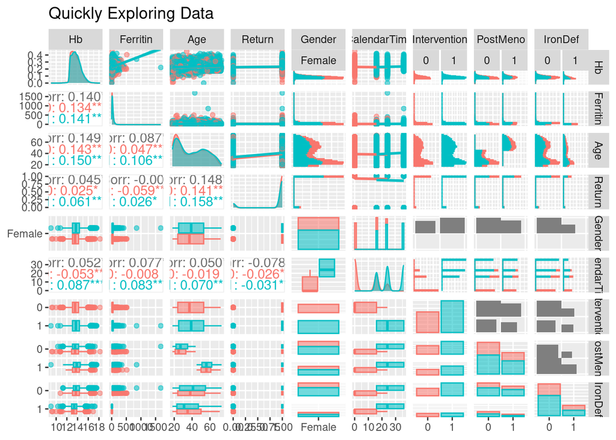

Plot by pairs

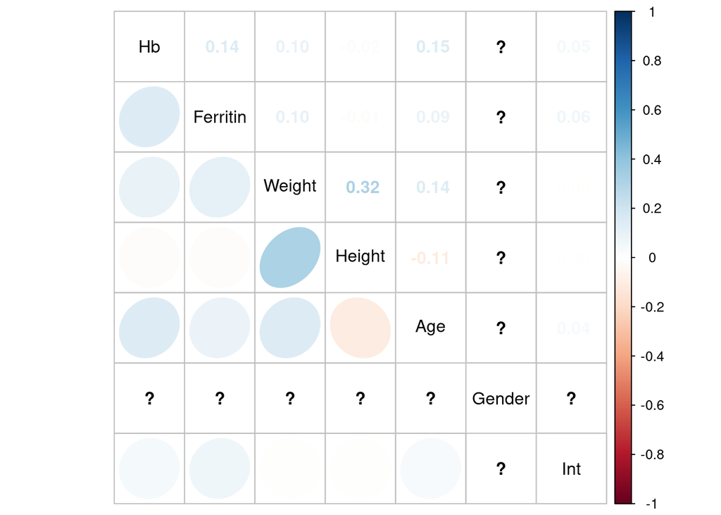

Correlation plot

```r
data_clean %>%
  na.omit() %>%
  dplyr::select(-KeyID, -stap2, -Meetweek, -Cluster, -HbDef, -Timepoint, -Step, -Weight, -Height, -Intervention_months,-COVID, -Donatiedatum, -ReturnOpTijd, -Intervention_months2, -Intervention_months_factor, -Step, -Donorcentrum_Cluster, -Donatiecentrumcode) %>%
  GGally::ggpairs(mapping = aes(fill    = Intervention,
                              col       = Intervention,
                              alpha     = 0.05),
                upper = list(continuous = "smooth",
                             combo      = "facethist",
                             discrete   = "ratio"),
                lower = list(continuous = "cor",
                             combo      = "box",
                             discrete   = "facetbar"),
                title = "Quickly Exploring Data")

data_clean %>%
  na.omit() %>%
  dplyr::select(Hb, Ferritin, Weight, Height, Age, Gender, Intervention) %>%
  mutate(Gender = as.numeric(Gender), Intervention = as.numeric(Intervention)) %>%
  rename(Int = Intervention) %>%
  cor() %>%
  corrplot.mixed(lower  = "ellipse",
                           upper  = "number",
                           tl.col = "black")
```

We produce an additional scaled and centered dataset. In this dataset, we additionally present ferritin on a Log10 scale.

```r
data_scale <- data_clean
data_scale$Age <- scale(data_scale$Age, center=TRUE, scale = FALSE)
data_scale$Weight <- scale(data_scale$Weight, center=TRUE, scale = FALSE)
data_scale$Height <- scale(data_scale$Height, center=TRUE, scale = FALSE)
data_scale$FerritinLog10 <- log10(data_scale$Ferritin)
```

# Descriptives

We present the data stratified by sex and menopausal status.

```r
#for table 1, we only use participants that were assigned to a cluster. Since we present the baseline characteristics of our study, we select only measurement week 0.
#we load additional data that counts the number of donations
data_teller <- read_sav("~/Amber/Data/FINDEM/baseline_teller.sav")
data_t1 <- data_clean%>% filter(!is.na(Cluster), Meetweek==0)
data_t1 <- merge(data_t1, data_teller,  by = "KeyID", all.x = T)
data_t1 <- data_t1 %>% mutate(stap3 = as.factor(stap2), stap3 = recode_factor(stap3, "2.1"="2","2.2"="2", "3.1"="3", "3.2"="3"), stap3 = factor(stap3,levels = c("1", "2", "3", "4")), Ndonation = TotaalOpBaseline, Ndonation = replace(Ndonation, Ndonation>0, 1), Ndonation = recode_factor(Ndonation, `1`="0", `0`= "1"))
```

## Premenopausal females

```r
prefemalest1<-table1::table1(~ Age + Hb + Ferritin + Height + Weight + TotaalOpBaseline + Previous2yr + factor(IronDef) + factor(HbDef) + factor(ReturnOpTijd) + factor(Ndonation) | factor(stap3), data = subset(data_t1, data_t1$Gender=="Female" & data_t1$PostMeno==0), caption = "Premenopausal females", render.continuous=c(.="Mean (SD)", .="Median [Q1, Q3]"), render.categorical=c(.="FREQ (PCT)"))
prefemalest1
```

Premenopausal females

|  | 1 (N=774) | 2 (N=717) | 3 (N=723) | 4 (N=481) | Overall (N=2695) |
| --- | --- | --- | --- | --- | --- |
| Age |  |  |  |  |  |
| Mean (SD) | 27.7 (7.93) | 28.3 (7.94) | 28.3 (7.75) | 27.1 (7.60) | 27.9 (7.84) |
| Median [Q1, Q3] | 26.0 [21.0, 34.0] | 26.0 [21.0, 35.0] | 26.0 [22.0, 34.0] | 25.0 [21.0, 32.0] | 26.0 [21.0, 34.0] |
| Hb |  |  |  |  |  |
| Mean (SD) | 13.5 (0.921) | 13.5 (0.910) | 13.5 (0.907) | 13.5 (0.917) | 13.5 (0.914) |
| Median [Q1, Q3] | 13.4 [12.7, 14.0] | 13.4 [12.9, 14.2] | 13.5 [12.9, 14.1] | 13.4 [12.9, 14.0] | 13.4 [12.9, 14.0] |
| Ferritin |  |  |  |  |  |
| Mean (SD) | 34.9 (35.3) | 34.7 (38.7) | 34.3 (28.9) | 32.4 (31.7) | 34.3 (34.0) |
| Median [Q1, Q3] | 26.1 [13.0, 47.6] | 24.7 [12.1, 46.4] | 26.1 [12.9, 48.7] | 24.2 [10.8, 41.2] | 25.4 [12.3, 46.1] |
| Missing | 156 (20.2%) | 108 (15.1%) | 104 (14.4%) | 86 (17.9%) | 454 (16.8%) |
| Height |  |  |  |  |  |
| Mean (SD) | 171 (7.34) | 171 (6.78) | 171 (6.26) | 171 (6.39) | 171 (6.75) |
| Median [Q1, Q3] | 170 [167, 175] | 171 [167, 175] | 171 [168, 175] | 171 [167, 175] | 171 [167, 175] |
| Missing | 2 (0.3%) | 0 (0%) | 1 (0.1%) | 0 (0%) | 3 (0.1%) |
| Weight |  |  |  |  |  |
| Mean (SD) | 71.3 (12.1) | 71.2 (12.7) | 71.6 (12.2) | 70.8 (12.0) | 71.3 (12.3) |
| Median [Q1, Q3] | 70.0 [63.0, 77.0] | 69.0 [62.0, 78.0] | 70.0 [63.0, 79.0] | 69.0 [63.0, 77.0] | 69.0 [63.0, 78.0] |
| Missing | 2 (0.3%) | 0 (0%) | 0 (0%) | 0 (0%) | 2 (0.1%) |
| TotaalOpBaseline |  |  |  |  |  |
| Mean (SD) | 5.73 (8.28) | 6.85 (9.06) | 7.24 (9.09) | 7.06 (9.33) | 6.67 (8.92) |
| Median [Q1, Q3] | 2.00 [1.00, 7.00] | 3.00 [1.00, 9.00] | 4.00 [1.00, 10.0] | 3.00 [1.00, 9.00] | 3.00 [1.00, 9.00] |
| Missing | 86 (11.1%) | 127 (17.7%) | 89 (12.3%) | 16 (3.3%) | 318 (11.8%) |
| Previous2yr |  |  |  |  |  |
| Mean (SD) | 2.53 (1.63) | 2.71 (1.67) | 2.74 (1.62) | 2.80 (1.59) | 2.68 (1.63) |
| Median [Q1, Q3] | 2.00 [1.00, 4.00] | 2.00 [1.00, 4.00] | 2.00 [1.00, 4.00] | 3.00 [1.00, 4.00] | 2.00 [1.00, 4.00] |
| Missing | 86 (11.1%) | 127 (17.7%) | 89 (12.3%) | 16 (3.3%) | 318 (11.8%) |
| factor(IronDef) |  |  |  |  |  |
| 0 | 437 (56.5) | 417 (58.2) | 427 (59.1) | 263 (54.7) | 1544 (57.3) |
| 1 | 181 (23.4) | 192 (26.8) | 192 (26.6) | 132 (27.4) | 697 (25.9) |
| Missing | 156 (20.2%) | 108 (15.1%) | 104 (14.4%) | 86 (17.9%) | 454 (16.8%) |
| factor(HbDef) |  |  |  |  |  |
| 0 | 703 (90.8) | 670 (93.4) | 673 (93.1) | 438 (91.1) | 2484 (92.2) |
| 1 | 71 (9.2) | 47 (6.6) | 50 (6.9) | 43 (8.9) | 211 (7.8) |
| factor(ReturnOpTijd) |  |  |  |  |  |
| 0 | 256 (33.1) | 280 (39.1) | 239 (33.1) | 151 (31.4) | 926 (34.4) |
| 1 | 518 (66.9) | 437 (60.9) | 484 (66.9) | 330 (68.6) | 1769 (65.6) |
| factor(Ndonation) |  |  |  |  |  |
| 0 | 521 (67.3) | 481 (67.1) | 503 (69.6) | 379 (78.8) | 1884 (69.9) |
| 1 | 167 (21.6) | 109 (15.2) | 131 (18.1) | 86 (17.9) | 493 (18.3) |
| Missing | 86 (11.1%) | 127 (17.7%) | 89 (12.3%) | 16 (3.3%) | 318 (11.8%) |

## Postmenopausal females

```r
postfemalest1<-table1(~ Age + Hb + Ferritin + Height + Weight +TotaalOpBaseline + Previous2yr + factor(IronDef) + factor(HbDef) + factor(Return) + factor(ReturnOpTijd) + factor(Ndonation) | factor(stap3), data = subset(data_t1, data_t1$Gender=="Female" & data_t1$PostMeno==1), caption = "Females", render.continuous=c(.="Mean (SD)", .="Median [Q1, Q3]"), render.categorical=c(.="FREQ (PCT)"))
postfemalest1
```

Females

|  | 1 (N=486) | 2 (N=505) | 3 (N=500) | 4 (N=334) | Overall (N=1825) |
| --- | --- | --- | --- | --- | --- |
| Age |  |  |  |  |  |
| Mean (SD) | 55.7 (6.75) | 55.6 (6.75) | 56.0 (6.48) | 55.7 (6.95) | 55.8 (6.71) |
| Median [Q1, Q3] | 55.0 [50.0, 61.0] | 55.0 [50.0, 61.0] | 56.0 [51.0, 61.0] | 55.0 [50.0, 62.0] | 55.0 [50.0, 61.0] |
| Hb |  |  |  |  |  |
| Mean (SD) | 13.8 (0.971) | 13.8 (0.941) | 13.8 (0.919) | 13.7 (0.937) | 13.8 (0.943) |
| Median [Q1, Q3] | 13.9 [13.1, 14.5] | 13.7 [13.1, 14.5] | 13.7 [13.1, 14.3] | 13.5 [13.1, 14.3] | 13.7 [13.1, 14.5] |
| Ferritin |  |  |  |  |  |
| Mean (SD) | 36.4 (33.0) | 36.7 (36.5) | 35.9 (34.7) | 34.8 (29.0) | 36.0 (33.8) |
| Median [Q1, Q3] | 29.4 [14.2, 46.9] | 29.2 [15.3, 46.7] | 28.1 [13.6, 46.6] | 27.6 [14.8, 45.2] | 28.4 [14.3, 46.6] |
| Missing | 115 (23.7%) | 78 (15.4%) | 87 (17.4%) | 52 (15.6%) | 332 (18.2%) |
| Height |  |  |  |  |  |
| Mean (SD) | 170 (5.92) | 169 (6.07) | 170 (6.09) | 169 (5.91) | 169 (6.01) |
| Median [Q1, Q3] | 170 [165, 173] | 168 [165, 173] | 170 [166, 174] | 170 [165, 174] | 170 [165, 173] |
| Missing | 0 (0%) | 0 (0%) | 1 (0.2%) | 0 (0%) | 1 (0.1%) |
| Weight |  |  |  |  |  |
| Mean (SD) | 74.8 (11.5) | 73.5 (12.3) | 73.8 (12.0) | 73.2 (11.7) | 73.9 (11.9) |
| Median [Q1, Q3] | 73.0 [67.0, 81.0] | 72.0 [64.0, 82.0] | 71.5 [65.0, 80.0] | 71.0 [65.0, 80.0] | 72.0 [65.0, 80.0] |
| TotaalOpBaseline |  |  |  |  |  |
| Mean (SD) | 32.3 (24.4) | 29.7 (21.7) | 31.1 (22.7) | 32.5 (23.7) | 31.4 (23.1) |
| Median [Q1, Q3] | 29.0 [11.0, 50.0] | 26.0 [12.0, 42.0] | 29.0 [12.0, 46.0] | 29.0 [12.0, 47.0] | 28.0 [12.0, 46.0] |
| Missing | 98 (20.2%) | 126 (25.0%) | 113 (22.6%) | 26 (7.8%) | 363 (19.9%) |
| Previous2yr |  |  |  |  |  |
| Mean (SD) | 4.41 (1.54) | 4.20 (1.53) | 4.28 (1.52) | 4.35 (1.40) | 4.31 (1.51) |
| Median [Q1, Q3] | 5.00 [3.00, 6.00] | 4.00 [3.00, 5.00] | 5.00 [3.00, 6.00] | 5.00 [3.00, 5.00] | 5.00 [3.00, 6.00] |
| Missing | 98 (20.2%) | 126 (25.0%) | 113 (22.6%) | 26 (7.8%) | 363 (19.9%) |
| factor(IronDef) |  |  |  |  |  |
| 0 | 272 (56.0) | 321 (63.6) | 294 (58.8) | 211 (63.2) | 1098 (60.2) |
| 1 | 99 (20.4) | 106 (21.0) | 119 (23.8) | 71 (21.3) | 395 (21.6) |
| Missing | 115 (23.7%) | 78 (15.4%) | 87 (17.4%) | 52 (15.6%) | 332 (18.2%) |
| factor(HbDef) |  |  |  |  |  |
| 0 | 462 (95.1) | 482 (95.4) | 476 (95.2) | 323 (96.7) | 1743 (95.5) |
| 1 | 24 (4.9) | 23 (4.6) | 24 (4.8) | 11 (3.3) | 82 (4.5) |
| factor(Return) |  |  |  |  |  |
| 0 | 18 (3.7) | 23 (4.6) | 18 (3.6) | 12 (3.6) | 71 (3.9) |
| 1 | 468 (96.3) | 482 (95.4) | 482 (96.4) | 322 (96.4) | 1754 (96.1) |
| factor(ReturnOpTijd) |  |  |  |  |  |
| 0 | 137 (28.2) | 147 (29.1) | 131 (26.2) | 90 (26.9) | 505 (27.7) |
| 1 | 349 (71.8) | 358 (70.9) | 369 (73.8) | 244 (73.1) | 1320 (72.3) |
| factor(Ndonation) |  |  |  |  |  |
| 0 | 377 (77.6) | 372 (73.7) | 374 (74.8) | 306 (91.6) | 1429 (78.3) |
| 1 | 11 (2.3) | 7 (1.4) | 13 (2.6) | 2 (0.6) | 33 (1.8) |
| Missing | 98 (20.2%) | 126 (25.0%) | 113 (22.6%) | 26 (7.8%) | 363 (19.9%) |

## Males

```r
malest1<- table1(~ Age + Hb + Ferritin + Height + Weight +TotaalOpBaseline + Previous2yr + factor(IronDef) + factor(HbDef) + factor(Return) + factor(ReturnOpTijd) + factor(Ndonation) | factor(stap3), data = subset(data_t1, data_t1$Gender=="Male"), caption = "Males", render.continuous=c(.="Mean (SD)", .="Median [Q1, Q3]"), render.categorical=c(.="FREQ (PCT)"))
malest1
```

Males

|  | 1 (N=1213) | 2 (N=1320) | 3 (N=1171) | 4 (N=956) | Overall (N=4660) |
| --- | --- | --- | --- | --- | --- |
| Age |  |  |  |  |  |
| Mean (SD) | 46.3 (14.8) | 47.9 (14.6) | 46.2 (14.8) | 46.4 (15.3) | 46.8 (14.9) |
| Median [Q1, Q3] | 49.0 [33.0, 59.0] | 51.0 [36.0, 60.0] | 49.0 [33.0, 58.0] | 50.0 [32.0, 59.0] | 50.0 [34.0, 59.0] |
| Hb |  |  |  |  |  |
| Mean (SD) | 15.0 (1.05) | 15.0 (1.03) | 15.0 (1.02) | 14.9 (0.999) | 15.0 (1.03) |
| Median [Q1, Q3] | 14.8 [14.2, 15.6] | 14.9 [14.2, 15.6] | 15.0 [14.2, 15.6] | 14.8 [14.2, 15.5] | 14.8 [14.2, 15.6] |
| Ferritin |  |  |  |  |  |
| Mean (SD) | 45.2 (52.2) | 47.4 (76.0) | 43.9 (55.2) | 41.0 (45.0) | 44.6 (59.6) |
| Median [Q1, Q3] | 27.0 [13.2, 57.5] | 27.9 [14.1, 57.2] | 26.3 [12.8, 54.2] | 25.2 [12.3, 53.4] | 26.7 [13.2, 55.7] |
| Missing | 212 (17.5%) | 157 (11.9%) | 161 (13.7%) | 129 (13.5%) | 659 (14.1%) |
| Height |  |  |  |  |  |
| Mean (SD) | 184 (7.05) | 183 (7.33) | 183 (6.95) | 183 (7.59) | 183 (7.23) |
| Median [Q1, Q3] | 183 [179, 188] | 183 [178, 187] | 183 [178, 188] | 183 [178, 188] | 183 [178, 188] |
| Weight |  |  |  |  |  |
| Mean (SD) | 86.5 (12.0) | 86.0 (12.2) | 85.8 (12.3) | 85.2 (11.8) | 85.9 (12.1) |
| Median [Q1, Q3] | 85.0 [78.0, 94.0] | 85.0 [78.0, 93.0] | 85.0 [78.0, 93.0] | 84.0 [77.0, 92.0] | 85.0 [78.0, 93.0] |
| Missing | 0 (0%) | 1 (0.1%) | 0 (0%) | 1 (0.1%) | 2 (0.0%) |
| TotaalOpBaseline |  |  |  |  |  |
| Mean (SD) | 40.8 (38.5) | 43.7 (37.5) | 40.2 (36.2) | 42.2 (39.7) | 41.7 (37.9) |
| Median [Q1, Q3] | 30.0 [7.00, 68.0] | 39.0 [8.00, 71.0] | 32.0 [8.00, 64.0] | 31.5 [7.00, 70.0] | 32.0 [7.00, 68.0] |
| Missing | 138 (11.4%) | 259 (19.6%) | 164 (14.0%) | 86 (9.0%) | 647 (13.9%) |
| Previous2yr |  |  |  |  |  |
| Mean (SD) | 6.03 (2.87) | 5.99 (2.92) | 6.02 (2.78) | 5.93 (2.83) | 6.00 (2.85) |
| Median [Q1, Q3] | 6.00 [4.00, 9.00] | 6.00 [4.00, 9.00] | 6.00 [4.00, 8.00] | 6.00 [4.00, 8.00] | 6.00 [4.00, 8.00] |
| Missing | 138 (11.4%) | 259 (19.6%) | 164 (14.0%) | 86 (9.0%) | 647 (13.9%) |
| factor(IronDef) |  |  |  |  |  |
| 0 | 706 (58.2) | 844 (63.9) | 713 (60.9) | 571 (59.7) | 2834 (60.8) |
| 1 | 295 (24.3) | 319 (24.2) | 297 (25.4) | 256 (26.8) | 1167 (25.0) |
| Missing | 212 (17.5%) | 157 (11.9%) | 161 (13.7%) | 129 (13.5%) | 659 (14.1%) |
| factor(HbDef) |  |  |  |  |  |
| 0 | 1170 (96.5) | 1288 (97.6) | 1131 (96.6) | 925 (96.8) | 4514 (96.9) |
| 1 | 43 (3.5) | 32 (2.4) | 40 (3.4) | 31 (3.2) | 146 (3.1) |
| factor(Return) |  |  |  |  |  |
| 0 | 64 (5.3) | 55 (4.2) | 66 (5.6) | 45 (4.7) | 230 (4.9) |
| 1 | 1149 (94.7) | 1265 (95.8) | 1105 (94.4) | 911 (95.3) | 4430 (95.1) |
| factor(ReturnOpTijd) |  |  |  |  |  |
| 0 | 184 (15.2) | 234 (17.7) | 193 (16.5) | 174 (18.2) | 785 (16.8) |
| 1 | 1029 (84.8) | 1086 (82.3) | 978 (83.5) | 782 (81.8) | 3875 (83.2) |
| factor(Ndonation) |  |  |  |  |  |
| 0 | 1017 (83.8) | 998 (75.6) | 961 (82.1) | 823 (86.1) | 3799 (81.5) |
| 1 | 58 (4.8) | 63 (4.8) | 46 (3.9) | 47 (4.9) | 214 (4.6) |
| Missing | 138 (11.4%) | 259 (19.6%) | 164 (14.0%) | 86 (9.0%) | 647 (13.9%) |

# Analysis

As defined in the protocol, we will fit linear mixed models with random effects for the donation center clusters. We start with analysis of the primary outcomes (Hb levels, ferritin levels, Hb deferral and iron deficiency). We stratify analyses by sex and for females by menopausal status.

## Linear Mixed Models (unscaled)

### Hb levels

```r
hb_fitM <- lmer(Hb ~ Age + Weight + Height + CalendarTime + Intervention_months_factor + (1|Cluster), data = data_clean, subset = data_clean$Gender == "Male")

hb_fit_preF <- lmer(Hb ~ Age + Weight + Height + CalendarTime + Intervention_months_factor + (1|Cluster), data = data_clean, subset = data_clean$Gender == "Female" & data_clean$PostMeno == 0)

hb_fit_postF <- lmer(Hb ~ Age + Weight + Height + CalendarTime + Intervention_months_factor + (1|Cluster), data = data_clean, subset = data_clean$Gender == "Female" & data_clean$PostMeno == 1)

pl <- c(
  `(Intercept)` = "Intercept",
  Intervention_months_factor1 = "6-11 months",
  Intervention_months_factor2 = "12-17 months",
  Intervention_months_factor3 = "18-23 months",
  Intervention_months_factor4 = "24-29 months",
  Intervention_months_factor5 = "30-35 months",
  Intervention_months_factor6 = "36+ months"
)

tab_model(hb_fit_preF, hb_fit_postF, hb_fitM, pred.labels = pl, dv.labels = c("Pre-menopausal women", "Post-menopausal women", "Men"), show.reflvl = T, title = "Hb levels", digits.re = 4)
```

Hb levels

|  | Pre-menopausal women |  |  | Post-menopausal women |  |  | Men |  |  |
| --- | --- | --- | --- | --- | --- | --- | --- | --- | --- |
| Predictors | Estimates | CI | p | Estimates | CI | p | Estimates | CI | p |
| Intercept | 13.16 | 12.74 – 13.57 | **<0.001** | 13.23 | 12.60 – 13.86 | **<0.001** | 15.50 | 15.10 – 15.90 | **<0.001** |
| Age | -0.00 | -0.00 – 0.00 | 0.581 | 0.01 | 0.01 – 0.02 | **<0.001** | -0.01 | -0.01 – -0.01 | **<0.001** |
| Weight | 0.00 | 0.00 – 0.01 | **<0.001** | 0.01 | 0.00 – 0.01 | **<0.001** | 0.01 | 0.01 – 0.01 | **<0.001** |
| Height | 0.00 | -0.00 – 0.00 | 0.908 | -0.00 | -0.01 – -0.00 | **0.018** | -0.01 | -0.01 – -0.01 | **<0.001** |
| CalendarTime | 0.00 | -0.00 – 0.00 | 0.725 | -0.00 | -0.00 – 0.00 | 0.888 | 0.00 | -0.00 – 0.00 | 0.104 |
| 6-11 months | 0.02 | -0.06 – 0.10 | 0.589 | 0.11 | 0.01 – 0.21 | **0.028** | 0.13 | 0.05 – 0.20 | **0.001** |
| 12-17 months | 0.08 | 0.01 – 0.14 | **0.021** | 0.05 | -0.04 – 0.13 | 0.258 | 0.19 | 0.13 – 0.25 | **<0.001** |
| 18-23 months | 0.16 | 0.07 – 0.25 | **<0.001** | 0.18 | 0.06 – 0.30 | **0.004** | 0.28 | 0.19 – 0.36 | **<0.001** |
| 24-29 months | 0.17 | 0.09 – 0.26 | **<0.001** | 0.18 | 0.08 – 0.29 | **0.001** | 0.29 | 0.22 – 0.37 | **<0.001** |
| 30-35 months | 0.04 | -0.08 – 0.16 | 0.509 | 0.09 | -0.06 – 0.25 | 0.249 | 0.25 | 0.14 – 0.37 | **<0.001** |
| 36+ months | 0.20 | 0.09 – 0.31 | **<0.001** | 0.17 | 0.04 – 0.31 | **0.013** | 0.34 | 0.24 – 0.44 | **<0.001** |
| Random Effects |  |  |  |  |  |  |  |  |  |
| σ<sup>2</sup> | 0.7908 |  |  | 0.8691 |  |  | 1.0209 |  |  |
| τ<sub>00</sub> | 0.0041 <sub>Cluster</sub> |  |  | 0.0059 <sub>Cluster</sub> |  |  | 0.0038 <sub>Cluster</sub> |  |  |
| ICC | 0.0052 |  |  | 0.0068 |  |  | 0.0037 |  |  |
| N | 29 <sub>Cluster</sub> |  |  | 29 <sub>Cluster</sub> |  |  | 29 <sub>Cluster</sub> |  |  |
| Observations | 11994 |  |  | 7682 |  |  | 17919 |  |  |
| Marginal R<sup>2</sup> / Conditional R<sup>2</sup> | 0.011 / 0.017 |  |  | 0.023 / 0.030 |  |  | 0.043 / 0.047 |  |  |

### Ferritin levels

```r
ferritin_fitM <- lmer(Ferritin ~ Age + Weight + Height + CalendarTime+ Intervention_months_factor + (1|Cluster), data = data_clean, subset = data_clean$Gender == "Male")

ferritin_fit_preF <- lmer(Ferritin ~ Age + Weight + Height + CalendarTime+ Intervention_months_factor + (1|Cluster), data = data_clean, subset = data_clean$Gender == "Female" & data_clean$PostMeno == 0)

ferritin_fit_postF <- lmer(Ferritin ~ Age + Weight + Height + CalendarTime+ Intervention_months_factor + (1|Cluster), data = data_clean, subset = data_clean$Gender == "Female" & data_clean$PostMeno == 1)
```

```
boundary (singular) fit: see help('isSingular')
```

```r
pl <- c(
  `(Intercept)` = "Intercept",
  Intervention_months_factor1 = "6-11 months",
  Intervention_months_factor2 = "12-17 months",
  Intervention_months_factor3 = "18-23 months",
  Intervention_months_factor4 = "24-29 months",
  Intervention_months_factor5 = "30-35 months",
  Intervention_months_factor6 = "36+ months"
)

tab_model(ferritin_fit_preF, ferritin_fit_postF, ferritin_fitM, pred.labels = pl, dv.labels = c("Pre-menopausal women", "Post-menopausal women", "Men"), show.reflvl = T, title = "Ferritin levels", digits.re = 4)
```

Ferritin levels

|  | Pre-menopausal women |  |  | Post-menopausal women |  |  | Men |  |  |
| --- | --- | --- | --- | --- | --- | --- | --- | --- | --- |
| Predictors | Estimates | CI | p | Estimates | CI | p | Estimates | CI | p |
| Intercept | 48.09 | 29.10 – 67.08 | **<0.001** | 44.40 | 18.56 – 70.24 | **0.001** | 129.29 | 103.86 – 154.72 | **<0.001** |
| Age | 0.26 | 0.17 – 0.36 | **<0.001** | 0.02 | -0.10 – 0.15 | 0.714 | -0.67 | -0.73 – -0.60 | **<0.001** |
| Weight | 0.28 | 0.22 – 0.34 | **<0.001** | 0.37 | 0.29 – 0.44 | **<0.001** | 0.73 | 0.64 – 0.81 | **<0.001** |
| Height | -0.25 | -0.36 – -0.13 | **<0.001** | -0.22 | -0.37 – -0.08 | **0.003** | -0.63 | -0.78 – -0.48 | **<0.001** |
| CalendarTime | 0.07 | -0.02 – 0.17 | 0.142 | 0.16 | 0.05 – 0.26 | **0.004** | 0.28 | 0.15 – 0.40 | **<0.001** |
| 6-11 months | -1.87 | -4.99 – 1.26 | 0.241 | -1.05 | -4.57 – 2.47 | 0.557 | -0.08 | -4.37 – 4.20 | 0.970 |
| 12-17 months | -0.17 | -2.78 – 2.45 | 0.900 | 3.71 | 0.76 – 6.66 | **0.014** | 7.71 | 4.18 – 11.23 | **<0.001** |
| 18-23 months | 0.13 | -3.54 – 3.81 | 0.943 | 5.31 | 1.21 – 9.40 | **0.011** | 8.67 | 3.74 – 13.59 | **0.001** |
| 24-29 months | 3.49 | 0.17 – 6.81 | **0.039** | 5.86 | 2.34 – 9.37 | **0.001** | 11.10 | 6.70 – 15.50 | **<0.001** |
| 30-35 months | 1.49 | -3.62 – 6.61 | 0.566 | 9.15 | 3.91 – 14.39 | **0.001** | 8.88 | 2.23 – 15.54 | **0.009** |
| 36+ months | 2.75 | -1.83 – 7.34 | 0.239 | 9.91 | 5.31 – 14.50 | **<0.001** | 11.74 | 5.96 – 17.52 | **<0.001** |
| Random Effects |  |  |  |  |  |  |  |  |  |
| σ<sup>2</sup> | 1280.0677 |  |  | 1257.6164 |  |  | 3587.6442 |  |  |
| τ<sub>00</sub> | 3.0117 <sub>Cluster</sub> |  |  | 0.0000 <sub>Cluster</sub> |  |  | 5.7085 <sub>Cluster</sub> |  |  |
| ICC | 0.0023 |  |  |  |  |  | 0.0016 |  |  |
| N | 29 <sub>Cluster</sub> |  |  | 29 <sub>Cluster</sub> |  |  | 29 <sub>Cluster</sub> |  |  |
| Observations | 9683 |  |  | 6534 |  |  | 15737 |  |  |
| Marginal R<sup>2</sup> / Conditional R<sup>2</sup> | 0.016 / 0.019 |  |  | 0.032 / NA |  |  | 0.050 / 0.052 |  |  |

We see that there is an issue regarding singularity in the model fit for postmenopausal females.

### Hb deferral

```r
hbdef_fitM <- glmer(formula = HbDef ~ Age + Weight + Height + CalendarTime+ Intervention_months_factor + (1|Cluster), data = data_clean, subset = data_clean$Gender == "Female" & data_clean$PostMeno == 0, family = binomial)
hbdef_fit_preF <- glmer(formula = HbDef ~ Age + Weight + Height + CalendarTime+ Intervention_months_factor + (1|Cluster), data = data_clean, subset = data_clean$Gender == "Female" & data_clean$PostMeno == 0, family = binomial)
hbdef_fit_postF <- glmer(formula = HbDef ~ Age + Weight + Height + CalendarTime+ Intervention_months_factor + (1|Cluster), data = data_clean, subset = data_clean$Gender == "Female" & data_clean$PostMeno == 1, family = binomial)
pl <- c(
  `(Intercept)` = "Intercept",
  Intervention_months_factor1 = "6-11 months",
  Intervention_months_factor2 = "12-17 months",
  Intervention_months_factor3 = "18-23 months",
  Intervention_months_factor4 = "24-29 months",
  Intervention_months_factor5 = "30-35 months",
  Intervention_months_factor6 = "36+ months"
)

tab_model(hbdef_fit_preF, hbdef_fit_postF, hbdef_fitM, pred.labels = pl, dv.labels = c("Pre-menopausal women", "Post-menopausal women", "Men"), show.reflvl = T, title = "Hb deferral", digits.re = 4)
```

Hb deferral

|  | Pre-menopausal women |  |  | Post-menopausal women |  |  | Men |  |  |
| --- | --- | --- | --- | --- | --- | --- | --- | --- | --- |
| Predictors | Odds Ratios | CI | p | Odds Ratios | CI | p | Odds Ratios | CI | p |
| Intercept | 1.59 | 0.28 – 8.95 | 0.602 | 7.78 | 0.24 – 247.87 | 0.245 | 1.59 | 0.28 – 8.95 | 0.602 |
| Age | 1.00 | 0.99 – 1.01 | 0.450 | 0.95 | 0.93 – 0.97 | **<0.001** | 1.00 | 0.99 – 1.01 | 0.450 |
| Weight | 0.99 | 0.98 – 0.99 | **<0.001** | 1.00 | 0.99 – 1.01 | 0.748 | 0.99 | 0.98 – 0.99 | **<0.001** |
| Height | 0.99 | 0.98 – 1.00 | **0.042** | 0.99 | 0.97 – 1.01 | 0.240 | 0.99 | 0.98 – 1.00 | **0.042** |
| CalendarTime | 1.00 | 0.99 – 1.01 | 0.375 | 1.00 | 0.98 – 1.01 | 0.908 | 1.00 | 0.99 – 1.01 | 0.375 |
| 6-11 months | 0.93 | 0.67 – 1.28 | 0.644 | 0.87 | 0.53 – 1.43 | 0.588 | 0.93 | 0.67 – 1.28 | 0.644 |
| 12-17 months | 0.85 | 0.65 – 1.12 | 0.253 | 0.83 | 0.55 – 1.24 | 0.365 | 0.85 | 0.65 – 1.12 | 0.253 |
| 18-23 months | 0.60 | 0.40 – 0.91 | **0.016** | 0.63 | 0.34 – 1.19 | 0.157 | 0.60 | 0.40 – 0.91 | **0.016** |
| 24-29 months | 0.66 | 0.46 – 0.96 | **0.028** | 0.46 | 0.26 – 0.83 | **0.009** | 0.66 | 0.46 – 0.96 | **0.028** |
| 30-35 months | 0.67 | 0.39 – 1.14 | 0.141 | 0.79 | 0.38 – 1.66 | 0.540 | 0.67 | 0.39 – 1.14 | 0.141 |
| 36+ months | 0.67 | 0.41 – 1.08 | 0.097 | 0.49 | 0.24 – 1.00 | 0.051 | 0.67 | 0.41 – 1.08 | 0.097 |
| Random Effects |  |  |  |  |  |  |  |  |  |
| σ<sup>2</sup> | 3.2899 |  |  | 3.2899 |  |  | 3.2899 |  |  |
| τ<sub>00</sub> | 0.0449 <sub>Cluster</sub> |  |  | 0.0135 <sub>Cluster</sub> |  |  | 0.0449 <sub>Cluster</sub> |  |  |
| ICC | 0.0135 |  |  | 0.0041 |  |  | 0.0135 |  |  |
| N | 29 <sub>Cluster</sub> |  |  | 29 <sub>Cluster</sub> |  |  | 29 <sub>Cluster</sub> |  |  |
| Observations | 11994 |  |  | 7682 |  |  | 11994 |  |  |
| Marginal R<sup>2</sup> / Conditional R<sup>2</sup> | 0.030 / 0.043 |  |  | 0.063 / 0.067 |  |  | 0.030 / 0.043 |  |  |

### Iron deficiency

```r
ID_fitM <- glmer(formula = IronDef ~ Age + Weight + Height + CalendarTime+ Intervention_months_factor + (1|Cluster), data = data_clean, subset = data_clean$Gender == "Female" & data_clean$PostMeno == 0, family = binomial)
ID_fit_preF <- glmer(formula = IronDef ~ Age + Weight + Height + CalendarTime+ Intervention_months_factor + (1|Cluster), data = data_clean, subset = data_clean$Gender == "Female" & data_clean$PostMeno == 0, family = binomial)
ID_fit_postF <- glmer(formula = IronDef ~ Age + Weight + Height + CalendarTime+ Intervention_months_factor + (1|Cluster), data = data_clean, subset = data_clean$Gender == "Female" & data_clean$PostMeno == 1, family = binomial)
pl <- c(
  `(Intercept)` = "Intercept",
  Intervention_months_factor1 = "6-11 months",
  Intervention_months_factor2 = "12-17 months",
  Intervention_months_factor3 = "18-23 months",
  Intervention_months_factor4 = "24-29 months",
  Intervention_months_factor5 = "30-35 months",
  Intervention_months_factor6 = "36+ months"
)

tab_model(hbdef_fit_preF, hbdef_fit_postF, hbdef_fitM, pred.labels = pl, dv.labels = c("Pre-menopausal women", "Post-menopausal women", "Men"), show.reflvl = T, title = "Iron deficiency", digits.re = 4)
```

Iron deficiency

|  | Pre-menopausal women |  |  | Post-menopausal women |  |  | Men |  |  |
| --- | --- | --- | --- | --- | --- | --- | --- | --- | --- |
| Predictors | Odds Ratios | CI | p | Odds Ratios | CI | p | Odds Ratios | CI | p |
| Intercept | 1.59 | 0.28 – 8.95 | 0.602 | 7.78 | 0.24 – 247.87 | 0.245 | 1.59 | 0.28 – 8.95 | 0.602 |
| Age | 1.00 | 0.99 – 1.01 | 0.450 | 0.95 | 0.93 – 0.97 | **<0.001** | 1.00 | 0.99 – 1.01 | 0.450 |
| Weight | 0.99 | 0.98 – 0.99 | **<0.001** | 1.00 | 0.99 – 1.01 | 0.748 | 0.99 | 0.98 – 0.99 | **<0.001** |
| Height | 0.99 | 0.98 – 1.00 | **0.042** | 0.99 | 0.97 – 1.01 | 0.240 | 0.99 | 0.98 – 1.00 | **0.042** |
| CalendarTime | 1.00 | 0.99 – 1.01 | 0.375 | 1.00 | 0.98 – 1.01 | 0.908 | 1.00 | 0.99 – 1.01 | 0.375 |
| 6-11 months | 0.93 | 0.67 – 1.28 | 0.644 | 0.87 | 0.53 – 1.43 | 0.588 | 0.93 | 0.67 – 1.28 | 0.644 |
| 12-17 months | 0.85 | 0.65 – 1.12 | 0.253 | 0.83 | 0.55 – 1.24 | 0.365 | 0.85 | 0.65 – 1.12 | 0.253 |
| 18-23 months | 0.60 | 0.40 – 0.91 | **0.016** | 0.63 | 0.34 – 1.19 | 0.157 | 0.60 | 0.40 – 0.91 | **0.016** |
| 24-29 months | 0.66 | 0.46 – 0.96 | **0.028** | 0.46 | 0.26 – 0.83 | **0.009** | 0.66 | 0.46 – 0.96 | **0.028** |
| 30-35 months | 0.67 | 0.39 – 1.14 | 0.141 | 0.79 | 0.38 – 1.66 | 0.540 | 0.67 | 0.39 – 1.14 | 0.141 |
| 36+ months | 0.67 | 0.41 – 1.08 | 0.097 | 0.49 | 0.24 – 1.00 | 0.051 | 0.67 | 0.41 – 1.08 | 0.097 |
| Random Effects |  |  |  |  |  |  |  |  |  |
| σ<sup>2</sup> | 3.2899 |  |  | 3.2899 |  |  | 3.2899 |  |  |
| τ<sub>00</sub> | 0.0449 <sub>Cluster</sub> |  |  | 0.0135 <sub>Cluster</sub> |  |  | 0.0449 <sub>Cluster</sub> |  |  |
| ICC | 0.0135 |  |  | 0.0041 |  |  | 0.0135 |  |  |
| N | 29 <sub>Cluster</sub> |  |  | 29 <sub>Cluster</sub> |  |  | 29 <sub>Cluster</sub> |  |  |
| Observations | 11994 |  |  | 7682 |  |  | 11994 |  |  |
| Marginal R<sup>2</sup> / Conditional R<sup>2</sup> | 0.030 / 0.043 |  |  | 0.063 / 0.067 |  |  | 0.030 / 0.043 |  |  |

**Decision**

The basic models for Hb deferral and iron deficiency in males and premenopausal females failed to converge. Because of this, we decided to scale the variables for all analyses.

## Linear Mixed Models (scaled)

### Hb levels

```r
hb_fitM <- lmer(Hb ~ Age + Weight + Height + CalendarTime+ Intervention_months_factor + (1|Cluster), data = data_scale, subset = data_scale$Gender == "Male")

hb_fit_preF <- lmer(Hb ~ Age + Weight + Height + CalendarTime+ Intervention_months_factor + (1|Cluster), data = data_scale, subset = data_scale$Gender == "Female" & data_scale$PostMeno == 0)

hb_fit_postF <- lmer(Hb ~ Age + Weight + Height + CalendarTime+ Intervention_months_factor + (1|Cluster), data = data_scale, subset = data_scale$Gender == "Female" & data_scale$PostMeno == 1)

pl <- c(
  `(Intercept)` = "Intercept",
  Intervention_months_factor1 = "6-11 months",
  Intervention_months_factor2 = "12-17 months",
  Intervention_months_factor3 = "18-23 months",
  Intervention_months_factor4 = "24-29 months",
  Intervention_months_factor5 = "30-35 months",
  Intervention_months_factor6 = "36+ months"
)

tab_model(hb_fit_preF, hb_fit_postF, hb_fitM, pred.labels = pl, dv.labels = c("Pre-menopausal women", "Post-menopausal women", "Men"), show.reflvl = T, title = "Hb levels", digits.re = 4)
```

Hb levels

|  | Pre-menopausal women |  |  | Post-menopausal women |  |  | Men |  |  |
| --- | --- | --- | --- | --- | --- | --- | --- | --- | --- |
| Predictors | Estimates | CI | p | Estimates | CI | p | Estimates | CI | p |
| Intercept | 13.49 | 13.43 – 13.54 | **<0.001** | 13.54 | 13.47 – 13.60 | **<0.001** | 14.89 | 14.85 – 14.93 | **<0.001** |
| Age | -0.00 | -0.00 – 0.00 | 0.581 | 0.01 | 0.01 – 0.02 | **<0.001** | -0.01 | -0.01 – -0.01 | **<0.001** |
| Weight | 0.00 | 0.00 – 0.01 | **<0.001** | 0.01 | 0.00 – 0.01 | **<0.001** | 0.01 | 0.01 – 0.01 | **<0.001** |
| Height | 0.00 | -0.00 – 0.00 | 0.908 | -0.00 | -0.01 – -0.00 | **0.018** | -0.01 | -0.01 – -0.01 | **<0.001** |
| CalendarTime | 0.00 | -0.00 – 0.00 | 0.725 | -0.00 | -0.00 – 0.00 | 0.888 | 0.00 | -0.00 – 0.00 | 0.104 |
| 6-11 months | 0.02 | -0.06 – 0.10 | 0.589 | 0.11 | 0.01 – 0.21 | **0.028** | 0.13 | 0.05 – 0.20 | **0.001** |
| 12-17 months | 0.08 | 0.01 – 0.14 | **0.021** | 0.05 | -0.04 – 0.13 | 0.258 | 0.19 | 0.13 – 0.25 | **<0.001** |
| 18-23 months | 0.16 | 0.07 – 0.25 | **<0.001** | 0.18 | 0.06 – 0.30 | **0.004** | 0.28 | 0.19 – 0.36 | **<0.001** |
| 24-29 months | 0.17 | 0.09 – 0.26 | **<0.001** | 0.18 | 0.08 – 0.29 | **0.001** | 0.29 | 0.22 – 0.37 | **<0.001** |
| 30-35 months | 0.04 | -0.08 – 0.16 | 0.509 | 0.09 | -0.06 – 0.25 | 0.249 | 0.25 | 0.14 – 0.37 | **<0.001** |
| 36+ months | 0.20 | 0.09 – 0.31 | **<0.001** | 0.17 | 0.04 – 0.31 | **0.013** | 0.34 | 0.24 – 0.44 | **<0.001** |
| Random Effects |  |  |  |  |  |  |  |  |  |
| σ<sup>2</sup> | 0.7908 |  |  | 0.8691 |  |  | 1.0209 |  |  |
| τ<sub>00</sub> | 0.0041 <sub>Cluster</sub> |  |  | 0.0059 <sub>Cluster</sub> |  |  | 0.0038 <sub>Cluster</sub> |  |  |
| ICC | 0.0052 |  |  | 0.0068 |  |  | 0.0037 |  |  |
| N | 29 <sub>Cluster</sub> |  |  | 29 <sub>Cluster</sub> |  |  | 29 <sub>Cluster</sub> |  |  |
| Observations | 11994 |  |  | 7682 |  |  | 17919 |  |  |
| Marginal R<sup>2</sup> / Conditional R<sup>2</sup> | 0.011 / 0.017 |  |  | 0.023 / 0.030 |  |  | 0.043 / 0.047 |  |  |

### Log10 Ferritin levels

```r
ferritin_fitM <- lmer(FerritinLog10 ~ Age + Weight + Height + CalendarTime+ Intervention_months_factor + (1|Cluster), data = data_scale, subset = data_scale$Gender == "Male")

ferritin_fit_preF <- lmer(FerritinLog10 ~ Age + Weight + Height + CalendarTime+ Intervention_months_factor + (1|Cluster), data = data_scale, subset = data_scale$Gender == "Female" & data_scale$PostMeno == 0)

ferritin_fit_postF <- lmer(FerritinLog10 ~ Age + Weight + Height + CalendarTime+ Intervention_months_factor + (1|Cluster), data = data_scale, subset = data_scale$Gender == "Female" & data_scale$PostMeno == 1)

pl <- c(
  `(Intercept)` = "Intercept",
  Intervention_months_factor1 = "6-11 months",
  Intervention_months_factor2 = "12-17 months",
  Intervention_months_factor3 = "18-23 months",
  Intervention_months_factor4 = "24-29 months",
  Intervention_months_factor5 = "30-35 months",
  Intervention_months_factor6 = "36+ months"
)

tab_model(ferritin_fit_preF, ferritin_fit_postF, ferritin_fitM, pred.labels = pl, dv.labels = c("Pre-menopausal women", "Post-menopausal women", "Men"), show.reflvl = T, title = "Log10 Ferritin levels", digits.re = 4)
```

Log10 Ferritin levels

|  | Pre-menopausal women |  |  | Post-menopausal women |  |  | Men |  |  |
| --- | --- | --- | --- | --- | --- | --- | --- | --- | --- |
| Predictors | Estimates | CI | p | Estimates | CI | p | Estimates | CI | p |
| Intercept | 1.37 | 1.35 – 1.40 | **<0.001** | 1.35 | 1.32 – 1.37 | **<0.001** | 1.44 | 1.43 – 1.46 | **<0.001** |
| Age | 0.00 | 0.00 – 0.00 | **<0.001** | 0.00 | 0.00 – 0.00 | **<0.001** | -0.00 | -0.00 – -0.00 | **<0.001** |
| Weight | 0.00 | 0.00 – 0.00 | **<0.001** | 0.00 | 0.00 – 0.00 | **<0.001** | 0.00 | 0.00 – 0.01 | **<0.001** |
| Height | -0.00 | -0.00 – -0.00 | **<0.001** | -0.00 | -0.00 – 0.00 | 0.116 | -0.00 | -0.00 – -0.00 | **<0.001** |
| CalendarTime | 0.00 | 0.00 – 0.00 | **0.020** | 0.00 | 0.00 – 0.00 | **0.002** | 0.00 | 0.00 – 0.00 | **<0.001** |
| 6-11 months | -0.00 | -0.04 – 0.03 | 0.829 | 0.02 | -0.02 – 0.06 | 0.336 | 0.05 | 0.02 – 0.08 | **0.002** |
| 12-17 months | 0.03 | 0.00 – 0.06 | **0.036** | 0.06 | 0.03 – 0.09 | **<0.001** | 0.12 | 0.10 – 0.15 | **<0.001** |
| 18-23 months | 0.04 | -0.01 – 0.08 | 0.112 | 0.08 | 0.03 – 0.12 | **0.001** | 0.12 | 0.09 – 0.16 | **<0.001** |
| 24-29 months | 0.06 | 0.02 – 0.10 | **0.003** | 0.11 | 0.07 – 0.14 | **<0.001** | 0.16 | 0.12 – 0.19 | **<0.001** |
| 30-35 months | 0.06 | -0.00 – 0.12 | 0.069 | 0.15 | 0.09 – 0.20 | **<0.001** | 0.14 | 0.09 – 0.19 | **<0.001** |
| 36+ months | 0.10 | 0.05 – 0.16 | **<0.001** | 0.17 | 0.12 – 0.22 | **<0.001** | 0.17 | 0.12 – 0.21 | **<0.001** |
| Random Effects |  |  |  |  |  |  |  |  |  |
| σ<sup>2</sup> | 0.1651 |  |  | 0.1345 |  |  | 0.1531 |  |  |
| τ<sub>00</sub> | 0.0008 <sub>Cluster</sub> |  |  | 0.0001 <sub>Cluster</sub> |  |  | 0.0006 <sub>Cluster</sub> |  |  |
| ICC | 0.0048 |  |  | 0.0009 |  |  | 0.0038 |  |  |
| N | 29 <sub>Cluster</sub> |  |  | 29 <sub>Cluster</sub> |  |  | 29 <sub>Cluster</sub> |  |  |
| Observations | 9683 |  |  | 6534 |  |  | 15737 |  |  |
| Marginal R<sup>2</sup> / Conditional R<sup>2</sup> | 0.023 / 0.028 |  |  | 0.050 / 0.051 |  |  | 0.088 / 0.092 |  |  |

### Hb deferral

```r
hbdef_fitM <- glmer(formula = HbDef ~ Age + Weight + Height + CalendarTime+ Intervention_months_factor + (1|Cluster), data = data_scale, subset = data_scale$Gender == "Female" & data_scale$PostMeno == 0, family = binomial)
hbdef_fit_preF <- glmer(formula = HbDef ~ Age + Weight + Height + CalendarTime+ Intervention_months_factor + (1|Cluster), data = data_scale, subset = data_scale$Gender == "Female" & data_scale$PostMeno == 0, family = binomial)
hbdef_fit_postF <- glmer(formula = HbDef ~ Age + Weight + Height + CalendarTime+ Intervention_months_factor + (1|Cluster), data = data_scale, subset = data_scale$Gender == "Female" & data_scale$PostMeno == 1, family = binomial)
pl <- c(
  `(Intercept)` = "Intercept",
  Intervention_months_factor1 = "6-11 months",
  Intervention_months_factor2 = "12-17 months",
  Intervention_months_factor3 = "18-23 months",
  Intervention_months_factor4 = "24-29 months",
  Intervention_months_factor5 = "30-35 months",
  Intervention_months_factor6 = "36+ months"
)

tab_model(hbdef_fit_preF, hbdef_fit_postF, hbdef_fitM, pred.labels = pl, dv.labels = c("Pre-menopausal women", "Post-menopausal women", "Men"), show.reflvl = T, title = "Hb deferral", digits.re = 4)
```

Hb deferral

|  | Pre-menopausal women |  |  | Post-menopausal women |  |  | Men |  |  |
| --- | --- | --- | --- | --- | --- | --- | --- | --- | --- |
| Predictors | Odds Ratios | CI | p | Odds Ratios | CI | p | Odds Ratios | CI | p |
| Intercept | 0.07 | 0.06 – 0.09 | **<0.001** | 0.09 | 0.07 – 0.12 | **<0.001** | 0.07 | 0.06 – 0.09 | **<0.001** |
| Age | 1.00 | 0.99 – 1.01 | 0.450 | 0.95 | 0.93 – 0.97 | **<0.001** | 1.00 | 0.99 – 1.01 | 0.450 |
| Weight | 0.99 | 0.98 – 0.99 | **<0.001** | 1.00 | 0.99 – 1.01 | 0.748 | 0.99 | 0.98 – 0.99 | **<0.001** |
| Height | 0.99 | 0.98 – 1.00 | **0.042** | 0.99 | 0.97 – 1.01 | 0.237 | 0.99 | 0.98 – 1.00 | **0.042** |
| CalendarTime | 1.00 | 0.99 – 1.01 | 0.375 | 1.00 | 0.98 – 1.01 | 0.908 | 1.00 | 0.99 – 1.01 | 0.375 |
| 6-11 months | 0.93 | 0.67 – 1.28 | 0.644 | 0.87 | 0.53 – 1.43 | 0.587 | 0.93 | 0.67 – 1.28 | 0.644 |
| 12-17 months | 0.85 | 0.65 – 1.12 | 0.253 | 0.83 | 0.55 – 1.24 | 0.365 | 0.85 | 0.65 – 1.12 | 0.253 |
| 18-23 months | 0.60 | 0.40 – 0.91 | **0.016** | 0.63 | 0.34 – 1.19 | 0.157 | 0.60 | 0.40 – 0.91 | **0.016** |
| 24-29 months | 0.66 | 0.46 – 0.96 | **0.028** | 0.46 | 0.26 – 0.83 | **0.009** | 0.66 | 0.46 – 0.96 | **0.028** |
| 30-35 months | 0.67 | 0.39 – 1.14 | 0.141 | 0.79 | 0.38 – 1.66 | 0.540 | 0.67 | 0.39 – 1.14 | 0.141 |
| 36+ months | 0.67 | 0.41 – 1.08 | 0.097 | 0.49 | 0.24 – 1.00 | 0.051 | 0.67 | 0.41 – 1.08 | 0.097 |
| Random Effects |  |  |  |  |  |  |  |  |  |
| σ<sup>2</sup> | 3.2899 |  |  | 3.2899 |  |  | 3.2899 |  |  |
| τ<sub>00</sub> | 0.0448 <sub>Cluster</sub> |  |  | 0.0135 <sub>Cluster</sub> |  |  | 0.0448 <sub>Cluster</sub> |  |  |
| ICC | 0.0134 |  |  | 0.0041 |  |  | 0.0134 |  |  |
| N | 29 <sub>Cluster</sub> |  |  | 29 <sub>Cluster</sub> |  |  | 29 <sub>Cluster</sub> |  |  |
| Observations | 11994 |  |  | 7682 |  |  | 11994 |  |  |
| Marginal R<sup>2</sup> / Conditional R<sup>2</sup> | 0.030 / 0.043 |  |  | 0.064 / 0.067 |  |  | 0.030 / 0.043 |  |  |

### Iron deficiency

```r
ID_fitM <- glmer(formula = IronDef ~ Age + Weight + Height + CalendarTime+ Intervention_months_factor + (1|Cluster), data = data_scale, subset = data_scale$Gender == "Female" & data_scale$PostMeno == 0, family = binomial)
ID_fit_preF <- glmer(formula = IronDef ~ Age + Weight + Height + CalendarTime+ Intervention_months_factor + (1|Cluster), data = data_scale, subset = data_scale$Gender == "Female" & data_scale$PostMeno == 0, family = binomial)
ID_fit_postF <- glmer(formula = IronDef ~ Age + Weight + Height + CalendarTime+ Intervention_months_factor + (1|Cluster), data = data_scale, subset = data_scale$Gender == "Female" & data_scale$PostMeno == 1, family = binomial)
pl <- c(
  `(Intercept)` = "Intercept",
  Intervention_months_factor1 = "6-11 months",
  Intervention_months_factor2 = "12-17 months",
  Intervention_months_factor3 = "18-23 months",
  Intervention_months_factor4 = "24-29 months",
  Intervention_months_factor5 = "30-35 months",
  Intervention_months_factor6 = "36+ months"
)

tab_model(hbdef_fit_preF, hbdef_fit_postF, hbdef_fitM, pred.labels = pl, dv.labels = c("Pre-menopausal women", "Post-menopausal women", "Men"), show.reflvl = T, title = "Iron deficiency", digits.re = 4)
```

Iron deficiency

|  | Pre-menopausal women |  |  | Post-menopausal women |  |  | Men |  |  |
| --- | --- | --- | --- | --- | --- | --- | --- | --- | --- |
| Predictors | Odds Ratios | CI | p | Odds Ratios | CI | p | Odds Ratios | CI | p |
| Intercept | 0.07 | 0.06 – 0.09 | **<0.001** | 0.09 | 0.07 – 0.12 | **<0.001** | 0.07 | 0.06 – 0.09 | **<0.001** |
| Age | 1.00 | 0.99 – 1.01 | 0.450 | 0.95 | 0.93 – 0.97 | **<0.001** | 1.00 | 0.99 – 1.01 | 0.450 |
| Weight | 0.99 | 0.98 – 0.99 | **<0.001** | 1.00 | 0.99 – 1.01 | 0.748 | 0.99 | 0.98 – 0.99 | **<0.001** |
| Height | 0.99 | 0.98 – 1.00 | **0.042** | 0.99 | 0.97 – 1.01 | 0.237 | 0.99 | 0.98 – 1.00 | **0.042** |
| CalendarTime | 1.00 | 0.99 – 1.01 | 0.375 | 1.00 | 0.98 – 1.01 | 0.908 | 1.00 | 0.99 – 1.01 | 0.375 |
| 6-11 months | 0.93 | 0.67 – 1.28 | 0.644 | 0.87 | 0.53 – 1.43 | 0.587 | 0.93 | 0.67 – 1.28 | 0.644 |
| 12-17 months | 0.85 | 0.65 – 1.12 | 0.253 | 0.83 | 0.55 – 1.24 | 0.365 | 0.85 | 0.65 – 1.12 | 0.253 |
| 18-23 months | 0.60 | 0.40 – 0.91 | **0.016** | 0.63 | 0.34 – 1.19 | 0.157 | 0.60 | 0.40 – 0.91 | **0.016** |
| 24-29 months | 0.66 | 0.46 – 0.96 | **0.028** | 0.46 | 0.26 – 0.83 | **0.009** | 0.66 | 0.46 – 0.96 | **0.028** |
| 30-35 months | 0.67 | 0.39 – 1.14 | 0.141 | 0.79 | 0.38 – 1.66 | 0.540 | 0.67 | 0.39 – 1.14 | 0.141 |
| 36+ months | 0.67 | 0.41 – 1.08 | 0.097 | 0.49 | 0.24 – 1.00 | 0.051 | 0.67 | 0.41 – 1.08 | 0.097 |
| Random Effects |  |  |  |  |  |  |  |  |  |
| σ<sup>2</sup> | 3.2899 |  |  | 3.2899 |  |  | 3.2899 |  |  |
| τ<sub>00</sub> | 0.0448 <sub>Cluster</sub> |  |  | 0.0135 <sub>Cluster</sub> |  |  | 0.0448 <sub>Cluster</sub> |  |  |
| ICC | 0.0134 |  |  | 0.0041 |  |  | 0.0134 |  |  |
| N | 29 <sub>Cluster</sub> |  |  | 29 <sub>Cluster</sub> |  |  | 29 <sub>Cluster</sub> |  |  |
| Observations | 11994 |  |  | 7682 |  |  | 11994 |  |  |
| Marginal R<sup>2</sup> / Conditional R<sup>2</sup> | 0.030 / 0.043 |  |  | 0.064 / 0.067 |  |  | 0.030 / 0.043 |  |  |

### Model summaries

```r
summary(hb_fitM)
## Linear mixed model fit by REML ['lmerMod']
## Formula:
## Hb ~ Age + Weight + Height + CalendarTime + Intervention_months_factor +
##     (1 | Cluster)
##    Data: data_scale
##  Subset: data_scale$Gender == "Male"
##
## REML criterion at convergence: 51331.8
##
## Scaled residuals:
##     Min      1Q  Median      3Q     Max
## -4.5862 -0.7460 -0.0590  0.6516  4.5617
##
## Random effects:
##  Groups   Name        Variance Std.Dev.
##  Cluster  (Intercept) 0.003803 0.06167
##  Residual             1.020858 1.01038
## Number of obs: 17919, groups:  Cluster, 29
##
## Fixed effects:
##                               Estimate Std. Error t value
## (Intercept)                 14.8899494  0.0195842 760.304
## Age                         -0.0064937  0.0005143 -12.626
## Weight                       0.0124544  0.0006854  18.172
## Height                      -0.0074577  0.0011882  -6.276
## CalendarTime                 0.0017973  0.0011045   1.627
## Intervention_months_factor1  0.1251101  0.0373124   3.353
## Intervention_months_factor2  0.1855178  0.0304708   6.088
## Intervention_months_factor3  0.2779015  0.0430486   6.456
## Intervention_months_factor4  0.2942056  0.0389549   7.552
## Intervention_months_factor5  0.2527217  0.0574740   4.397
## Intervention_months_factor6  0.3422857  0.0506786   6.754
##
## Correlation of Fixed Effects:
##             (Intr) Age    Weight Height ClndrT Int__1 Int__2 Int__3 Int__4
## Age         -0.155
## Weight      -0.052 -0.250
## Height      -0.316  0.250 -0.436
## CalendarTim -0.394  0.017  0.009 -0.007
## Intrvntn__1 -0.014 -0.004 -0.004 -0.001 -0.428
## Intrvntn__2  0.057  0.004 -0.014  0.005 -0.679  0.347
## Intrvntn__3  0.085  0.000 -0.001  0.000 -0.626  0.470  0.474
## Intrvntn__4  0.080  0.001 -0.012  0.002 -0.681  0.342  0.607  0.471
## Intrvntn__5  0.121  0.001  0.001 -0.009 -0.639  0.430  0.474  0.539  0.472
## Intrvntn__6  0.137 -0.005 -0.001 -0.002 -0.740  0.358  0.621  0.500  0.637
##             Int__5
## Age
## Weight
## Height
## CalendarTim
## Intrvntn__1
## Intrvntn__2
## Intrvntn__3
## Intrvntn__4
## Intrvntn__5
## Intrvntn__6  0.503
summary(hb_fit_preF)
## Linear mixed model fit by REML ['lmerMod']
## Formula:
## Hb ~ Age + Weight + Height + CalendarTime + Intervention_months_factor +
##     (1 | Cluster)
##    Data: data_scale
##  Subset: data_scale$Gender == "Female" & data_scale$PostMeno == 0
##
## REML criterion at convergence: 31327.7
##
## Scaled residuals:
##     Min      1Q  Median      3Q     Max
## -5.9483 -0.7159 -0.0796  0.6457  5.2872
##
## Random effects:
##  Groups   Name        Variance Std.Dev.
##  Cluster  (Intercept) 0.004121 0.0642
##  Residual             0.790778 0.8893
## Number of obs: 11994, groups:  Cluster, 29
##
## Fixed effects:
##                               Estimate Std. Error t value
## (Intercept)                 13.4850856  0.0258116 522.443
## Age                         -0.0005912  0.0010726  -0.551
## Weight                       0.0041465  0.0006337   6.543
## Height                       0.0001470  0.0012700   0.116
## CalendarTime                 0.0004374  0.0012443   0.351
## Intervention_months_factor1  0.0213866  0.0395776   0.540
## Intervention_months_factor2  0.0757623  0.0326953   2.317
## Intervention_months_factor3  0.1642168  0.0457611   3.589
## Intervention_months_factor4  0.1720944  0.0424402   4.055
## Intervention_months_factor5  0.0401763  0.0607889   0.661
## Intervention_months_factor6  0.2004685  0.0557672   3.595
##
## Correlation of Fixed Effects:
##             (Intr) Age    Weight Height ClndrT Int__1 Int__2 Int__3 Int__4
## Age          0.572
## Weight       0.004 -0.161
## Height       0.234  0.023 -0.297
## CalendarTim -0.354 -0.011  0.007  0.017
## Intrvntn__1 -0.004  0.001 -0.002  0.000 -0.446
## Intrvntn__2  0.045 -0.009  0.003 -0.011 -0.694  0.376
## Intrvntn__3  0.085 -0.004 -0.003 -0.006 -0.655  0.504  0.513
## Intrvntn__4  0.067 -0.013 -0.010 -0.007 -0.690  0.365  0.636  0.502
## Intrvntn__5  0.121  0.001  0.007 -0.006 -0.676  0.474  0.518  0.595  0.508
## Intrvntn__6  0.123 -0.006 -0.006 -0.025 -0.754  0.382  0.652  0.533  0.654
##             Int__5
## Age
## Weight
## Height
## CalendarTim
## Intrvntn__1
## Intrvntn__2
## Intrvntn__3
## Intrvntn__4
## Intrvntn__5
## Intrvntn__6  0.543
summary(hb_fit_postF)
## Linear mixed model fit by REML ['lmerMod']
## Formula:
## Hb ~ Age + Weight + Height + CalendarTime + Intervention_months_factor +
##     (1 | Cluster)
##    Data: data_scale
##  Subset: data_scale$Gender == "Female" & data_scale$PostMeno == 1
##
## REML criterion at convergence: 20819.5
##
## Scaled residuals:
##     Min      1Q  Median      3Q     Max
## -5.4697 -0.7213 -0.0551  0.6284  4.2455
##
## Random effects:
##  Groups   Name        Variance Std.Dev.
##  Cluster  (Intercept) 0.005948 0.07712
##  Residual             0.869087 0.93225
## Number of obs: 7682, groups:  Cluster, 29
##
## Fixed effects:
##                               Estimate Std. Error t value
## (Intercept)                 13.5386786  0.0333478 405.984
## Age                          0.0138426  0.0015496   8.933
## Weight                       0.0060244  0.0008093   7.444
## Height                      -0.0042320  0.0017925  -2.361
## CalendarTime                -0.0002209  0.0015726  -0.140
## Intervention_months_factor1  0.1125864  0.0513414   2.193
## Intervention_months_factor2  0.0479359  0.0424006   1.131
## Intervention_months_factor3  0.1767093  0.0607785   2.907
## Intervention_months_factor4  0.1834276  0.0539361   3.401
## Intervention_months_factor5  0.0912245  0.0790827   1.154
## Intervention_months_factor6  0.1741301  0.0703996   2.473
##
## Correlation of Fixed Effects:
##             (Intr) Age    Weight Height ClndrT Int__1 Int__2 Int__3 Int__4
## Age         -0.567
## Weight      -0.006  0.037
## Height       0.245  0.158 -0.270
## CalendarTim -0.335 -0.011 -0.006 -0.004
## Intrvntn__1 -0.017 -0.006 -0.005 -0.002 -0.434
## Intrvntn__2  0.043  0.008  0.008  0.009 -0.687  0.371
## Intrvntn__3  0.081 -0.016  0.006 -0.006 -0.628  0.476  0.493
## Intrvntn__4  0.071 -0.007  0.006 -0.010 -0.687  0.361  0.623  0.485
## Intrvntn__5  0.099 -0.007  0.001 -0.015 -0.648  0.445  0.497  0.544  0.491
## Intrvntn__6  0.118  0.001 -0.010  0.003 -0.746  0.375  0.638  0.512  0.644
##             Int__5
## Age
## Weight
## Height
## CalendarTim
## Intrvntn__1
## Intrvntn__2
## Intrvntn__3
## Intrvntn__4
## Intrvntn__5
## Intrvntn__6  0.521
```

```r
summary(ferritin_fitM)
## Linear mixed model fit by REML ['lmerMod']
## Formula:
## FerritinLog10 ~ Age + Weight + Height + CalendarTime + Intervention_months_factor +
##     (1 | Cluster)
##    Data: data_scale
##  Subset: data_scale$Gender == "Male"
##
## REML criterion at convergence: 15253.4
##
## Scaled residuals:
##     Min      1Q  Median      3Q     Max
## -9.2244 -0.6687 -0.0042  0.6764  4.7643
##
## Random effects:
##  Groups   Name        Variance  Std.Dev.
##  Cluster  (Intercept) 0.0005829 0.02414
##  Residual             0.1530956 0.39127
## Number of obs: 15737, groups:  Cluster, 29
##
## Fixed effects:
##                               Estimate Std. Error t value
## (Intercept)                  1.4436304  0.0079704 181.124
## Age                         -0.0043700  0.0002129 -20.524
## Weight                       0.0047712  0.0002838  16.814
## Height                      -0.0035278  0.0004898  -7.202
## CalendarTime                 0.0026945  0.0004514   5.969
## Intervention_months_factor1  0.0477389  0.0150797   3.166
## Intervention_months_factor2  0.1225644  0.0123468   9.927
## Intervention_months_factor3  0.1222907  0.0175215   6.979
## Intervention_months_factor4  0.1555082  0.0158422   9.816
## Intervention_months_factor5  0.1399058  0.0238687   5.861
## Intervention_months_factor6  0.1653309  0.0209583   7.889
##
## Correlation of Fixed Effects:
##             (Intr) Age    Weight Height ClndrT Int__1 Int__2 Int__3 Int__4
## Age         -0.146
## Weight      -0.057 -0.248
## Height      -0.321  0.248 -0.433
## CalendarTim -0.408  0.012  0.010 -0.010
## Intrvntn__1 -0.015  0.001 -0.008  0.000 -0.422
## Intrvntn__2  0.052 -0.008 -0.013  0.004 -0.662  0.342
## Intrvntn__3  0.085 -0.003  0.002  0.004 -0.616  0.463  0.463
## Intrvntn__4  0.081 -0.006 -0.011  0.002 -0.669  0.337  0.597  0.460
## Intrvntn__5  0.124 -0.013 -0.002 -0.004 -0.621  0.416  0.455  0.520  0.454
## Intrvntn__6  0.140 -0.022 -0.002 -0.003 -0.721  0.349  0.603  0.483  0.618
##             Int__5
## Age
## Weight
## Height
## CalendarTim
## Intrvntn__1
## Intrvntn__2
## Intrvntn__3
## Intrvntn__4
## Intrvntn__5
## Intrvntn__6  0.480
summary(ferritin_fit_preF)
## Linear mixed model fit by REML ['lmerMod']
## Formula:
## FerritinLog10 ~ Age + Weight + Height + CalendarTime + Intervention_months_factor +
##     (1 | Cluster)
##    Data: data_scale
##  Subset: data_scale$Gender == "Female" & data_scale$PostMeno == 0
##
## REML criterion at convergence: 10153.8
##
## Scaled residuals:
##     Min      1Q  Median      3Q     Max
## -8.5680 -0.5901  0.0855  0.6780  4.4314
##
## Random effects:
##  Groups   Name        Variance  Std.Dev.
##  Cluster  (Intercept) 0.0008036 0.02835
##  Residual             0.1651107 0.40634
## Number of obs: 9683, groups:  Cluster, 29
##
## Fixed effects:
##                               Estimate Std. Error t value
## (Intercept)                  1.3740883  0.0127909 107.427
## Age                          0.0021664  0.0005480   3.953
## Weight                       0.0032888  0.0003643   9.028
## Height                      -0.0024768  0.0006709  -3.692
## CalendarTime                 0.0014148  0.0006088   2.324
## Intervention_months_factor1 -0.0041022  0.0190175  -0.216
## Intervention_months_factor2  0.0333243  0.0159037   2.095
## Intervention_months_factor3  0.0358757  0.0225922   1.588
## Intervention_months_factor4  0.0609067  0.0205995   2.957
## Intervention_months_factor5  0.0573369  0.0314871   1.821
## Intervention_months_factor6  0.1011738  0.0284497   3.556
##
## Correlation of Fixed Effects:
##             (Intr) Age    Weight Height ClndrT Int__1 Int__2 Int__3 Int__4
## Age          0.593
## Weight       0.001 -0.183
## Height       0.245  0.035 -0.333
## CalendarTim -0.372 -0.024  0.007  0.016
## Intrvntn__1 -0.002  0.008 -0.002 -0.003 -0.441
## Intrvntn__2  0.024 -0.014  0.002 -0.015 -0.655  0.368
## Intrvntn__3  0.076 -0.009 -0.001 -0.005 -0.623  0.482  0.476
## Intrvntn__4  0.058 -0.010 -0.008 -0.020 -0.664  0.359  0.611  0.471
## Intrvntn__5  0.111 -0.011  0.022 -0.007 -0.624  0.434  0.463  0.536  0.459
## Intrvntn__6  0.110 -0.012  0.009 -0.034 -0.701  0.360  0.594  0.480  0.600
##             Int__5
## Age
## Weight
## Height
## CalendarTim
## Intrvntn__1
## Intrvntn__2
## Intrvntn__3
## Intrvntn__4
## Intrvntn__5
## Intrvntn__6  0.472
summary(ferritin_fit_postF)
## Linear mixed model fit by REML ['lmerMod']
## Formula:
## FerritinLog10 ~ Age + Weight + Height + CalendarTime + Intervention_months_factor +
##     (1 | Cluster)
##    Data: data_scale
##  Subset: data_scale$Gender == "Female" & data_scale$PostMeno == 1
##
## REML criterion at convergence: 5527
##
## Scaled residuals:
##     Min      1Q  Median      3Q     Max
## -9.7255 -0.5723  0.0641  0.6514  3.7354
##
## Random effects:
##  Groups   Name        Variance  Std.Dev.
##  Cluster  (Intercept) 0.0001204 0.01097
##  Residual             0.1344944 0.36673
## Number of obs: 6534, groups:  Cluster, 29
##
## Fixed effects:
##                               Estimate Std. Error t value
## (Intercept)                  1.3478317  0.0129216 104.308
## Age                          0.0030237  0.0006599   4.582
## Weight                       0.0032112  0.0004084   7.863
## Height                      -0.0012214  0.0007761  -1.574
## CalendarTime                 0.0018424  0.0005840   3.155
## Intervention_months_factor1  0.0184546  0.0191666   0.963
## Intervention_months_factor2  0.0625423  0.0159824   3.913
## Intervention_months_factor3  0.0750646  0.0223691   3.356
## Intervention_months_factor4  0.1053370  0.0193864   5.434
## Intervention_months_factor5  0.1451406  0.0288646   5.028
## Intervention_months_factor6  0.1687492  0.0254072   6.642
##
## Correlation of Fixed Effects:
##             (Intr) Age    Weight Height ClndrT Int__1 Int__2 Int__3 Int__4
## Age         -0.620
## Weight      -0.018  0.045
## Height       0.262  0.154 -0.328
## CalendarTim -0.387 -0.022  0.004 -0.007
## Intrvntn__1 -0.048 -0.004 -0.015  0.004 -0.350
## Intrvntn__2  0.024 -0.002  0.007  0.014 -0.602  0.351
## Intrvntn__3  0.069 -0.014  0.006 -0.009 -0.561  0.335  0.458
## Intrvntn__4  0.048 -0.012 -0.007 -0.010 -0.587  0.324  0.514  0.432
## Intrvntn__5  0.100 -0.010  0.002 -0.010 -0.567  0.306  0.437  0.410  0.414
## Intrvntn__6  0.115 -0.007 -0.004 -0.001 -0.647  0.319  0.515  0.443  0.494
##             Int__5
## Age
## Weight
## Height
## CalendarTim
## Intrvntn__1
## Intrvntn__2
## Intrvntn__3
## Intrvntn__4
## Intrvntn__5
## Intrvntn__6  0.430
```

**Decision**

Which indicates that the random effects of the donation center clusters in these analyses are of minimal importance and can be disregarded.

## Linear Regression

### Hb levels

```r
hb_fitM <- lm(Hb ~ Age + Weight + Height + CalendarTime + Intervention_months_factor, data = data_scale, subset = data_scale$Gender == "Male")
hb_fit_preF <- lm(Hb ~ Age + Weight + Height + CalendarTime + Intervention_months_factor, data = data_scale, subset = data_scale$Gender == "Female" & data_scale$PostMeno == 0)
hb_fit_postF <- lm(Hb ~ Age + Weight + Height + CalendarTime + Intervention_months_factor, data = data_scale, subset = data_scale$Gender == "Female" & data_scale$PostMeno == 1)

pl <- c(
  `(Intercept)` = "Intercept",
  Intervention_months_factor1 = "6-11 months",
  Intervention_months_factor2 = "12-17 months",
  Intervention_months_factor3 = "18-23 months",
  Intervention_months_factor4 = "24-29 months",
  Intervention_months_factor5 = "30-35 months",
  Intervention_months_factor6 = "36+ months"
)

tab_model(hb_fit_preF, hb_fit_postF, hb_fitM, pred.labels = pl, dv.labels = c("Pre-menopausal women", "Post-menopausal women", "Men"), show.reflvl = T, title = "Hb levels", p.style = "numeric", digits.p=5)
```

Hb levels

|  | Pre-menopausal women |  |  | Post-menopausal women |  |  | Men |  |  |
| --- | --- | --- | --- | --- | --- | --- | --- | --- | --- |
| Predictors | Estimates | CI | p | Estimates | CI | p | Estimates | CI | p |
| Intercept | 13.49 | 13.44 – 13.53 | **<0.00001** | 13.55 | 13.49 – 13.61 | **<0.00001** | 14.89 | 14.86 – 14.92 | **<0.00001** |
| Age | -0.00 | -0.00 – 0.00 | 0.75627 | 0.01 | 0.01 – 0.02 | **<0.00001** | -0.01 | -0.01 – -0.01 | **<0.00001** |
| Weight | 0.00 | 0.00 – 0.01 | **<0.00001** | 0.01 | 0.00 – 0.01 | **<0.00001** | 0.01 | 0.01 – 0.01 | **<0.00001** |
| Height | 0.00 | -0.00 – 0.00 | 0.85652 | -0.00 | -0.01 – -0.00 | **0.01220** | -0.01 | -0.01 – -0.01 | **<0.00001** |
| CalendarTime | 0.00 | 0.00 – 0.00 | **0.04561** | 0.00 | -0.00 – 0.00 | 0.86631 | 0.00 | 0.00 – 0.00 | **0.00464** |
| 6-11 months | -0.00 | -0.07 – 0.06 | 0.91381 | 0.09 | 0.00 – 0.18 | **0.03858** | 0.11 | 0.05 – 0.17 | **0.00063** |
| 12-17 months | 0.04 | -0.02 – 0.09 | 0.17244 | 0.04 | -0.03 – 0.11 | 0.28479 | 0.17 | 0.11 – 0.22 | **<0.00001** |
| 18-23 months | 0.13 | 0.05 – 0.20 | **0.00075** | 0.16 | 0.06 – 0.27 | **0.00145** | 0.26 | 0.19 – 0.33 | **<0.00001** |
| 24-29 months | 0.12 | 0.05 – 0.18 | **0.00052** | 0.16 | 0.08 – 0.25 | **0.00021** | 0.26 | 0.20 – 0.32 | **<0.00001** |
| 30-35 months | -0.03 | -0.12 – 0.06 | 0.53673 | 0.07 | -0.06 – 0.19 | 0.30197 | 0.21 | 0.12 – 0.31 | **<0.00001** |
| 36+ months | 0.12 | 0.03 – 0.20 | **0.00743** | 0.16 | 0.05 – 0.27 | **0.00443** | 0.30 | 0.22 – 0.38 | **<0.00001** |
| Observations | 11994 |  |  | 7682 |  |  | 17919 |  |  |
| R<sup>2</sup> / R<sup>2</sup> adjusted | 0.010 / 0.010 |  |  | 0.023 / 0.022 |  |  | 0.042 / 0.041 |  |  |

### Ferritin levels

```r
ferritin_fitM <- lm(FerritinLog10 ~ Age + Weight + Height + CalendarTime + Intervention_months_factor, data = data_scale, subset = data_scale$Gender == "Male")
ferritin_fit_preF <- lm(FerritinLog10 ~ Age + Weight + Height + CalendarTime + Intervention_months_factor, data = data_scale, subset = data_scale$Gender == "Female" & data_scale$PostMeno == 0)
ferritin_fit_postF <- lm(FerritinLog10 ~ Age + Weight + Height + CalendarTime + Intervention_months_factor, data = data_scale, subset = data_scale$Gender == "Female" & data_scale$PostMeno == 1)

pl <- c(
  `(Intercept)` = "Intercept",
  Intervention_months_factor1 = "6-11 months",
  Intervention_months_factor2 = "12-17 months",
  Intervention_months_factor3 = "18-23 months",
  Intervention_months_factor4 = "24-29 months",
  Intervention_months_factor5 = "30-35 months",
  Intervention_months_factor6 = "36+ months"
)

tab_model(ferritin_fit_preF, ferritin_fit_postF, ferritin_fitM, pred.labels = pl, dv.labels = c("Pre-menopausal women", "Post-menopausal women", "Men"), show.reflvl = T, title = "Ferritin levels",digits.p=5)
```

Ferritin levels

|  | Pre-menopausal women |  |  | Post-menopausal women |  |  | Men |  |  |
| --- | --- | --- | --- | --- | --- | --- | --- | --- | --- |
| Predictors | Estimates | CI | p | Estimates | CI | p | Estimates | CI | p |
| Intercept | 1.38 | 1.35 – 1.40 | **<0.00001** | 1.35 | 1.32 – 1.37 | **<0.00001** | 1.44 | 1.43 – 1.46 | **<0.00001** |
| Age | 0.00 | 0.00 – 0.00 | **0.00002** | 0.00 | 0.00 – 0.00 | **0.00001** | -0.00 | -0.00 – -0.00 | **<0.00001** |
| Weight | 0.00 | 0.00 – 0.00 | **<0.00001** | 0.00 | 0.00 – 0.00 | **<0.00001** | 0.00 | 0.00 – 0.01 | **<0.00001** |
| Height | -0.00 | -0.00 – -0.00 | **0.00018** | -0.00 | -0.00 – 0.00 | 0.11034 | -0.00 | -0.00 – -0.00 | **<0.00001** |
| CalendarTime | 0.00 | 0.00 – 0.00 | **0.00617** | 0.00 | 0.00 – 0.00 | **0.00071** | 0.00 | 0.00 – 0.00 | **<0.00001** |
| 6-11 months | -0.00 | -0.03 – 0.03 | 0.91746 | 0.01 | -0.02 – 0.05 | 0.42943 | 0.05 | 0.03 – 0.08 | **0.00005** |
| 12-17 months | 0.03 | 0.01 – 0.06 | **0.01233** | 0.06 | 0.03 – 0.09 | **0.00009** | 0.13 | 0.11 – 0.15 | **<0.00001** |
| 18-23 months | 0.04 | 0.00 – 0.08 | **0.04165** | 0.07 | 0.03 – 0.11 | **0.00095** | 0.13 | 0.10 – 0.16 | **<0.00001** |
| 24-29 months | 0.06 | 0.03 – 0.09 | **0.00031** | 0.10 | 0.07 – 0.14 | **<0.00001** | 0.17 | 0.15 – 0.20 | **<0.00001** |
| 30-35 months | 0.06 | 0.01 – 0.12 | **0.01498** | 0.14 | 0.09 – 0.20 | **<0.00001** | 0.16 | 0.12 – 0.20 | **<0.00001** |
| 36+ months | 0.10 | 0.06 – 0.15 | **0.00001** | 0.17 | 0.12 – 0.21 | **<0.00001** | 0.18 | 0.15 – 0.22 | **<0.00001** |
| Observations | 9683 |  |  | 6534 |  |  | 15737 |  |  |
| R<sup>2</sup> / R<sup>2</sup> adjusted | 0.023 / 0.022 |  |  | 0.050 / 0.048 |  |  | 0.091 / 0.090 |  |  |

## Logistic Regression

### Hb deferral

```r
hbdef_fitM <- glm(formula = HbDef ~ Age + Weight + Height + CalendarTime + Intervention_months_factor, data = data_scale, subset = data_scale$Gender == "Male" ,family = binomial)

hbdef_fit_preF <- glm(formula = HbDef ~ Age + Weight + Height + CalendarTime + Intervention_months_factor, data = data_scale, subset = data_scale$Gender == "Female" & data_scale$PostMeno == 0,family = binomial)

hbdef_fit_postF <- glm(formula = HbDef ~ Age + Weight + Height + CalendarTime + Intervention_months_factor, data = data_scale, subset = data_scale$Gender == "Female" & data_scale$PostMeno == 1,family = binomial)

pl <- c(
  `(Intercept)` = "Intercept",
  Intervention_months_factor1 = "6-11 months",
  Intervention_months_factor2 = "12-17 months",
  Intervention_months_factor3 = "18-23 months",
  Intervention_months_factor4 = "24-29 months",
  Intervention_months_factor5 = "30-35 months",
  Intervention_months_factor6 = "36+ months"
)

tab_model(hbdef_fit_preF, hbdef_fit_postF, hbdef_fitM, pred.labels = pl, dv.labels = c("Pre-menopausal women", "Post-menopausal women", "Men"), show.reflvl = T, title = "Hb deferral",digits.p=5)
```

Hb deferral

|  | Pre-menopausal women |  |  | Post-menopausal women |  |  | Men |  |  |
| --- | --- | --- | --- | --- | --- | --- | --- | --- | --- |
| Predictors | Odds Ratios | CI | p | Odds Ratios | CI | p | Odds Ratios | CI | p |
| Intercept | 0.07 | 0.06 – 0.09 | **<0.00001** | 0.09 | 0.07 – 0.12 | **<0.00001** | 0.04 | 0.03 – 0.04 | **<0.00001** |
| Age | 0.99 | 0.99 – 1.00 | 0.29218 | 0.95 | 0.93 – 0.97 | **<0.00001** | 1.02 | 1.01 – 1.03 | **<0.00001** |
| Weight | 0.99 | 0.98 – 0.99 | **0.00016** | 1.00 | 0.99 – 1.01 | 0.75561 | 0.97 | 0.96 – 0.98 | **<0.00001** |
| Height | 0.99 | 0.98 – 1.00 | **0.04702** | 0.99 | 0.97 – 1.01 | 0.23996 | 1.00 | 0.99 – 1.02 | 0.97174 |
| CalendarTime | 0.99 | 0.98 – 1.00 | 0.09106 | 1.00 | 0.98 – 1.01 | 0.85275 | 1.00 | 0.99 – 1.01 | 0.52149 |
| 6-11 months | 0.96 | 0.71 – 1.27 | 0.76959 | 0.90 | 0.55 – 1.41 | 0.65737 | 0.77 | 0.52 – 1.10 | 0.16391 |
| 12-17 months | 0.91 | 0.72 – 1.16 | 0.46265 | 0.84 | 0.56 – 1.24 | 0.38706 | 0.47 | 0.33 – 0.66 | **0.00002** |
| 18-23 months | 0.64 | 0.44 – 0.91 | **0.01531** | 0.66 | 0.35 – 1.17 | 0.17009 | 0.33 | 0.18 – 0.55 | **0.00007** |
| 24-29 months | 0.74 | 0.54 – 1.01 | 0.05826 | 0.47 | 0.26 – 0.81 | **0.00872** | 0.41 | 0.26 – 0.63 | **0.00009** |
| 30-35 months | 0.68 | 0.42 – 1.07 | 0.10570 | 0.81 | 0.39 – 1.61 | 0.56348 | 0.21 | 0.08 – 0.47 | **0.00043** |
| 36+ months | 0.81 | 0.54 – 1.20 | 0.29408 | 0.50 | 0.25 – 0.98 | 0.05122 | 0.21 | 0.10 – 0.40 | **0.00001** |
| Observations | 11994 |  |  | 7682 |  |  | 17919 |  |  |
| R<sup>2</sup> Tjur | 0.005 |  |  | 0.007 |  |  | 0.009 |  |  |

### Iron deficiency

```r
ID_fitM <- glm(formula = IronDef ~ Age + Weight + Height + CalendarTime + Intervention_months_factor, data = data_scale, subset = data_scale$Gender == "Male" ,family = binomial)

ID_fit_preF <- glm(formula = IronDef ~ Age + Weight + Height + CalendarTime + Intervention_months_factor, data = data_scale, subset = data_scale$Gender == "Female" & data_scale$PostMeno == 0,family = binomial)

ID_fit_postF <- glm(formula = IronDef ~ Age + Weight + Height + CalendarTime + Intervention_months_factor, data = data_scale, subset = data_scale$Gender == "Female" & data_scale$PostMeno == 1,family = binomial)

pl <- c(
  `(Intercept)` = "Intercept",
  Intervention_months_factor1 = "6-11 months",
  Intervention_months_factor2 = "12-17 months",
  Intervention_months_factor3 = "18-23 months",
  Intervention_months_factor4 = "24-29 months",
  Intervention_months_factor5 = "30-35 months",
  Intervention_months_factor6 = "36+ months"
)

tab_model(ID_fit_preF, ID_fit_postF, ID_fitM, pred.labels = pl, dv.labels = c("Pre-menopausal women", "Post-menopausal women", "Men"), show.reflvl = T, title = "Iron deficiency",digits.p=5)
```

Iron deficiency

|  | Pre-menopausal women |  |  | Post-menopausal women |  |  | Men |  |  |
| --- | --- | --- | --- | --- | --- | --- | --- | --- | --- |
| Predictors | Odds Ratios | CI | p | Odds Ratios | CI | p | Odds Ratios | CI | p |
| Intercept | 0.39 | 0.34 – 0.44 | **<0.00001** | 0.53 | 0.45 – 0.63 | **<0.00001** | 0.43 | 0.39 – 0.46 | **<0.00001** |
| Age | 0.99 | 0.99 – 1.00 | **0.00326** | 0.97 | 0.96 – 0.98 | **<0.00001** | 1.01 | 1.01 – 1.01 | **<0.00001** |
| Weight | 0.98 | 0.98 – 0.99 | **<0.00001** | 0.99 | 0.98 – 0.99 | **0.00008** | 0.98 | 0.97 – 0.98 | **<0.00001** |
| Height | 1.01 | 1.00 – 1.02 | **0.00248** | 1.00 | 0.99 – 1.01 | 0.53292 | 1.01 | 1.00 – 1.02 | **0.01402** |
| CalendarTime | 1.00 | 0.99 – 1.00 | 0.14050 | 0.99 | 0.98 – 1.00 | **0.01318** | 0.99 | 0.99 – 1.00 | **0.00036** |
| 6-11 months | 1.13 | 0.95 – 1.34 | 0.16481 | 0.90 | 0.70 – 1.14 | 0.37388 | 0.61 | 0.51 – 0.72 | **<0.00001** |
| 12-17 months | 0.81 | 0.70 – 0.94 | **0.00606** | 0.68 | 0.55 – 0.84 | **0.00035** | 0.33 | 0.28 – 0.39 | **<0.00001** |
| 18-23 months | 0.74 | 0.60 – 0.92 | **0.00587** | 0.55 | 0.40 – 0.75 | **0.00020** | 0.27 | 0.21 – 0.35 | **<0.00001** |
| 24-29 months | 0.70 | 0.58 – 0.85 | **0.00027** | 0.48 | 0.37 – 0.64 | **<0.00001** | 0.19 | 0.15 – 0.24 | **<0.00001** |
| 30-35 months | 0.69 | 0.51 – 0.92 | **0.01327** | 0.31 | 0.18 – 0.50 | **<0.00001** | 0.19 | 0.13 – 0.27 | **<0.00001** |
| 36+ months | 0.49 | 0.37 – 0.64 | **<0.00001** | 0.24 | 0.15 – 0.37 | **<0.00001** | 0.24 | 0.18 – 0.31 | **<0.00001** |
| Observations | 9683 |  |  | 6534 |  |  | 15737 |  |  |
| R<sup>2</sup> Tjur | 0.018 |  |  | 0.040 |  |  | 0.073 |  |  |

### Donor return (on time)

```r
returnOT_fitM <- glm(formula = ReturnOpTijd ~ Age + Weight + Height + CalendarTime + Intervention_months_factor, data = data_scale, subset = data_scale$Gender == "Male",family = binomial)
returnOT_fit_preF <- glm(formula = ReturnOpTijd ~ Age + Weight + Height + CalendarTime + Intervention_months_factor, data = data_scale, subset = data_scale$Gender == "Female" & data_scale$PostMeno == 0,family = binomial)
returnOT_fit_postF <- glm(formula = ReturnOpTijd ~ Age + Weight + Height + CalendarTime + Intervention_months_factor, data = data_scale, subset = data_scale$Gender == "Female" & data_scale$PostMeno == 1,family = binomial)

pl <- c(
  `(Intercept)` = "Intercept",
  Intervention_months_factor1 = "6-11 months",
  Intervention_months_factor2 = "12-17 months",
  Intervention_months_factor3 = "18-23 months",
  Intervention_months_factor4 = "24-29 months",
  Intervention_months_factor5 = "30-35 months",
  Intervention_months_factor6 = "36+ months"
)

tab_model(returnOT_fit_preF, returnOT_fit_postF, returnOT_fitM, pred.labels = pl, dv.labels = c("Pre-menopausal women", "Post-menopausal women", "Men"), show.reflvl = T, title = "Donor return (on time)",digits.p=5)
```

Donor return (on time)

|  | Pre-menopausal women |  |  | Post-menopausal women |  |  | Men |  |  |
| --- | --- | --- | --- | --- | --- | --- | --- | --- | --- |
| Predictors | Odds Ratios | CI | p | Odds Ratios | CI | p | Odds Ratios | CI | p |
| Intercept | 1.97 | 1.78 – 2.19 | **<0.00001** | 2.49 | 2.18 – 2.85 | **<0.00001** | 4.37 | 4.05 – 4.73 | **<0.00001** |
| Age | 1.00 | 1.00 – 1.01 | 0.81360 | 1.00 | 0.99 – 1.01 | 0.97831 | 1.01 | 1.01 – 1.01 | **<0.00001** |
| Weight | 1.00 | 1.00 – 1.01 | **0.02107** | 1.00 | 1.00 – 1.00 | 0.57437 | 1.01 | 1.00 – 1.01 | **0.00026** |
| Height | 1.01 | 1.00 – 1.01 | **0.04987** | 1.01 | 1.00 – 1.02 | 0.08678 | 1.00 | 0.99 – 1.01 | 0.95133 |
| CalendarTime | 0.99 | 0.99 – 1.00 | **0.00097** | 1.00 | 1.00 – 1.01 | 0.73066 | 1.00 | 1.00 – 1.01 | 0.36657 |
| 6-11 months | 0.89 | 0.77 – 1.04 | 0.15208 | 0.92 | 0.75 – 1.13 | 0.41264 | 0.78 | 0.66 – 0.91 | **0.00145** |
| 12-17 months | 0.99 | 0.87 – 1.12 | 0.82050 | 0.79 | 0.67 – 0.94 | **0.00743** | 0.83 | 0.72 – 0.95 | **0.00590** |
| 18-23 months | 0.98 | 0.83 – 1.16 | 0.79270 | 0.63 | 0.51 – 0.80 | **0.00009** | 0.67 | 0.56 – 0.80 | **<0.00001** |
| 24-29 months | 0.78 | 0.67 – 0.90 | **0.00105** | 0.58 | 0.48 – 0.70 | **<0.00001** | 0.59 | 0.51 – 0.69 | **<0.00001** |
| 30-35 months | 0.98 | 0.80 – 1.22 | 0.88750 | 0.77 | 0.58 – 1.03 | 0.07473 | 0.62 | 0.50 – 0.78 | **0.00002** |
| 36+ months | 1.13 | 0.93 – 1.37 | 0.21467 | 0.80 | 0.62 – 1.03 | 0.08278 | 0.55 | 0.45 – 0.66 | **<0.00001** |
| Observations | 11994 |  |  | 7683 |  |  | 17919 |  |  |
| R<sup>2</sup> Tjur | 0.006 |  |  | 0.008 |  |  | 0.011 |  |  |

### Donor return adjusted for COVID

```r
returnOT_fitM <- glm(formula = ReturnOpTijd ~ Age + Weight + Height + COVID + CalendarTime + Intervention_months_factor, data = data_scale, subset = data_scale$Gender == "Male",family = binomial)
returnOT_fit_preF <- glm(formula = ReturnOpTijd ~ Age + Weight + Height + COVID + CalendarTime + Intervention_months_factor, data = data_scale, subset = data_scale$Gender == "Female" & data_scale$PostMeno == 0,family = binomial)
returnOT_fit_postF <- glm(formula = ReturnOpTijd ~ Age + Weight + Height + COVID + CalendarTime + Intervention_months_factor, data = data_scale, subset = data_scale$Gender == "Female" & data_scale$PostMeno == 1,family = binomial)

pl <- c(
  `(Intercept)` = "Intercept",
  Intervention_months_factor1 = "6-11 months",
  Intervention_months_factor2 = "12-17 months",
  Intervention_months_factor3 = "18-23 months",
  Intervention_months_factor4 = "24-29 months",
  Intervention_months_factor5 = "30-35 months",
  Intervention_months_factor6 = "36+ months"
)

tab_model(returnOT_fit_preF, returnOT_fit_postF, returnOT_fitM, pred.labels = pl, dv.labels = c("Pre-menopausal women", "Post-menopausal women", "Men"), show.reflvl = T, title = "Donor return (on time)",digits.p=5)
```

Donor return (on time)

|  | Pre-menopausal women |  |  | Post-menopausal women |  |  | Men |  |  |
| --- | --- | --- | --- | --- | --- | --- | --- | --- | --- |
| Predictors | Odds Ratios | CI | p | Odds Ratios | CI | p | Odds Ratios | CI | p |
| Intercept | 2.01 | 1.81 – 2.23 | **<0.00001** | 2.57 | 2.24 – 2.94 | **<0.00001** | 4.44 | 4.11 – 4.80 | **<0.00001** |
| Age | 1.00 | 1.00 – 1.01 | 0.72382 | 1.00 | 0.99 – 1.01 | 0.89975 | 1.01 | 1.01 – 1.01 | **<0.00001** |
| Weight | 1.00 | 1.00 – 1.01 | **0.01983** | 1.00 | 1.00 – 1.00 | 0.57086 | 1.01 | 1.00 – 1.01 | **0.00024** |
| Height | 1.01 | 1.00 – 1.01 | 0.06010 | 1.01 | 1.00 – 1.02 | 0.08193 | 1.00 | 0.99 – 1.01 | 0.93806 |
| COVID1 | 0.81 | 0.73 – 0.89 | **0.00002** | 0.66 | 0.59 – 0.75 | **<0.00001** | 0.83 | 0.75 – 0.91 | **0.00012** |
| CalendarTime | 0.99 | 0.99 – 1.00 | **0.02074** | 1.00 | 1.00 – 1.01 | 0.11428 | 1.00 | 1.00 – 1.01 | 0.08589 |
| 6-11 months | 0.94 | 0.81 – 1.10 | 0.46156 | 1.02 | 0.83 – 1.26 | 0.84072 | 0.81 | 0.69 – 0.95 | **0.00977** |
| 12-17 months | 0.95 | 0.83 – 1.08 | 0.39585 | 0.74 | 0.63 – 0.88 | **0.00065** | 0.80 | 0.70 – 0.92 | **0.00132** |
| 18-23 months | 1.01 | 0.85 – 1.19 | 0.94647 | 0.67 | 0.53 – 0.84 | **0.00046** | 0.68 | 0.58 – 0.81 | **0.00001** |
| 24-29 months | 0.84 | 0.72 – 0.97 | **0.02250** | 0.66 | 0.54 – 0.81 | **0.00005** | 0.63 | 0.54 – 0.73 | **<0.00001** |
| 30-35 months | 0.90 | 0.72 – 1.11 | 0.31959 | 0.65 | 0.48 – 0.87 | **0.00355** | 0.57 | 0.46 – 0.71 | **<0.00001** |
| 36+ months | 1.03 | 0.84 – 1.25 | 0.78464 | 0.67 | 0.52 – 0.87 | **0.00250** | 0.50 | 0.41 – 0.61 | **<0.00001** |
| Observations | 11994 |  |  | 7683 |  |  | 17919 |  |  |
| R<sup>2</sup> Tjur | 0.007 |  |  | 0.013 |  |  | 0.012 |  |  |

## Model assumptions

### Hb levels

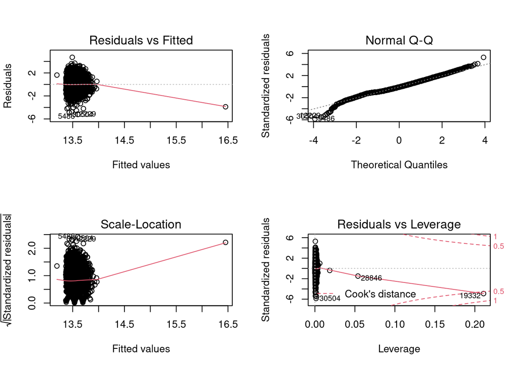

```r
par(mfrow = c(2, 2))
plot(hb_fit_preF)
```

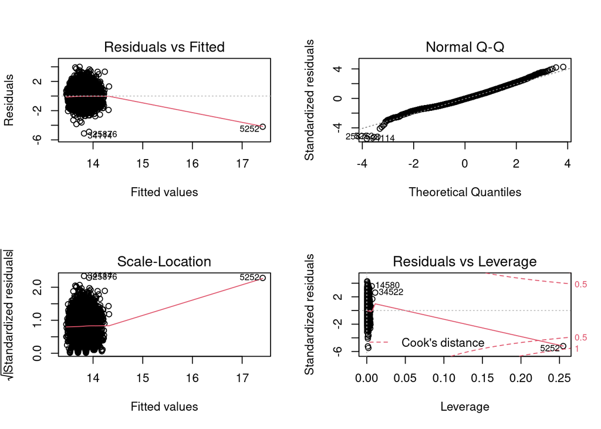

```r
plot(hb_fit_postF)
```

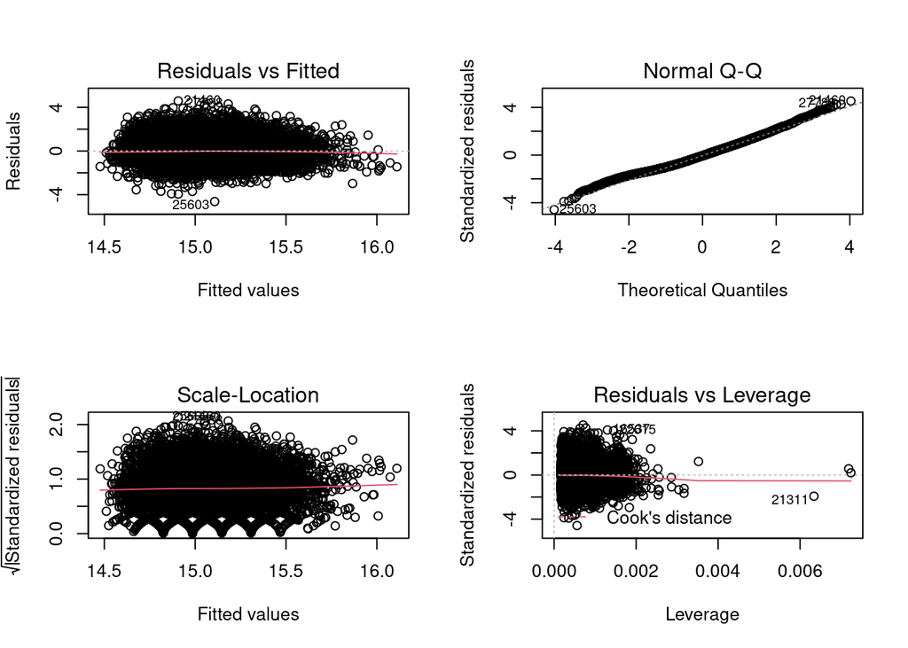

```r
plot(hb_fitM)
```

### Ferritin levels

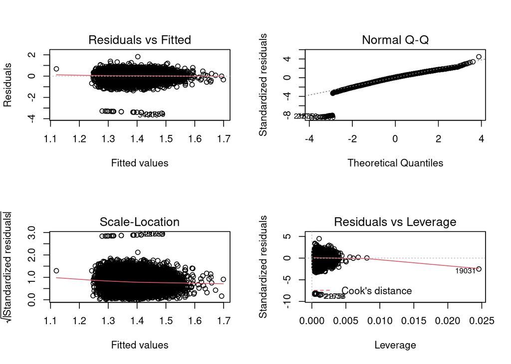

```r
par(mfrow = c(2, 2))
plot(ferritin_fit_preF)
```

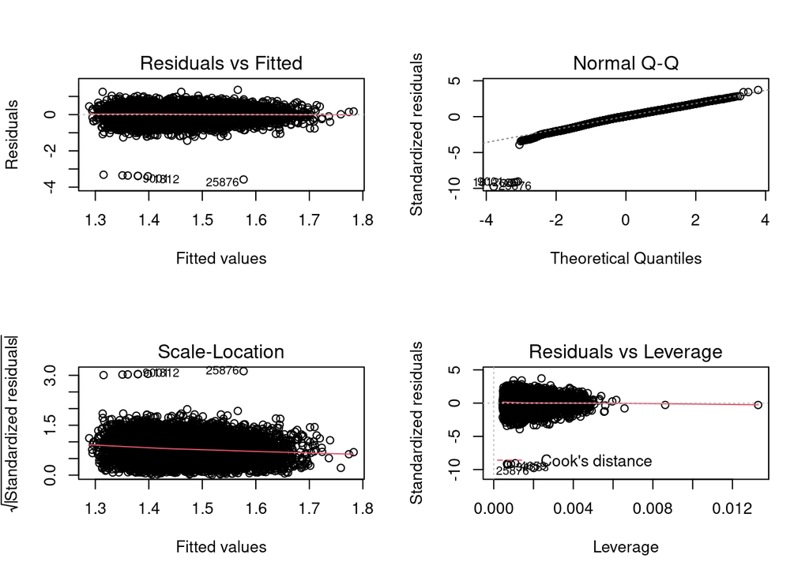

```r
plot(ferritin_fit_postF)
```

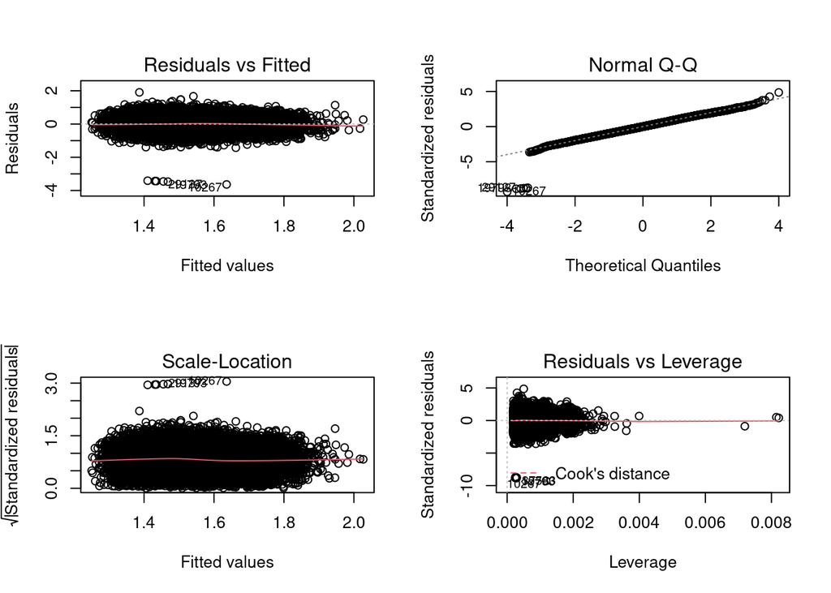

```r
plot(ferritin_fitM)
```

### Hb deferral

Independent observations: yes, we checked clustering with the LMM. Moreover, there is no longitudinal dependence.

Influential observations:

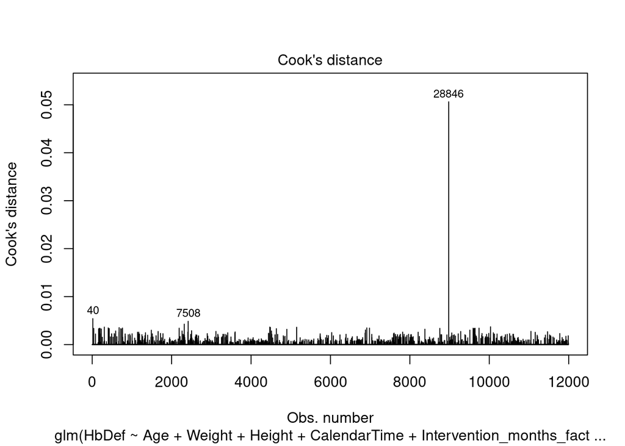

```r
plot(hbdef_fit_preF, which = 4) #this one has one quite curious observation so i want to look at the standardized residual
```

```r
model.data <- augment(hbdef_fit_preF) %>%
  dplyr::mutate(index = 1:n())
model.data %>% top_n(3, .cooksd) #the absolute standardized residual is not above 3 so we don't have to worry about this outlier.
```

```
# A tibble: 3 × 14
  .rownames HbDef Age[,1] Weight[,1] Height[,1] CalendarTime
  <chr>     <fct>   <dbl>      <dbl>      <dbl>        <dbl>
1 40        1      -14.2        31.4     -10.5            36
2 7508      1       -1.22       53.4      -6.50           16
3 28846     1      -17.2       -18.6    -169.             24
# ℹ 8 more variables: Intervention_months_factor <fct>, .fitted <dbl>,
#   .resid <dbl>, .hat <dbl>, .sigma <dbl>, .cooksd <dbl>, .std.resid <dbl>,
#   index <int>
```

Since this observation has a quite curious cook’s distance, we looked at the absolute standardized residual. However, it’s not above 3 so we don’t have to worry about it.

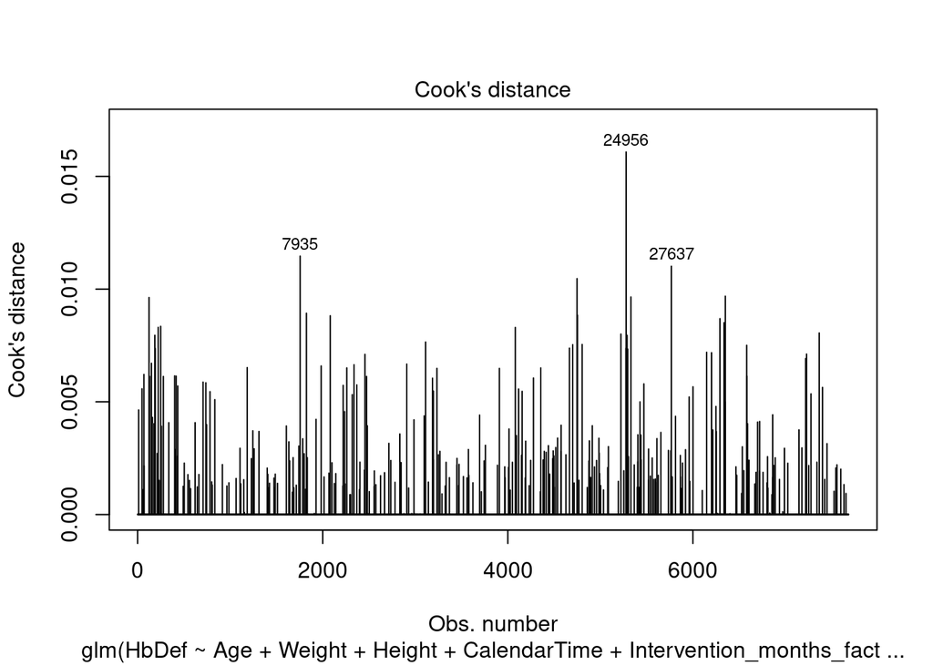

```r
plot(hbdef_fit_postF, which = 4)
```

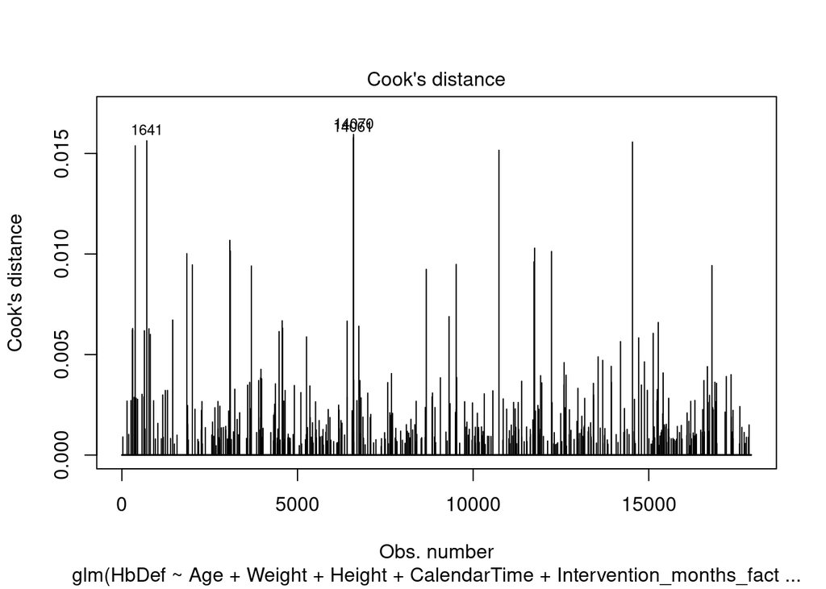

```r
plot(hbdef_fitM, which = 4)
```

```r
#no multicollinearity:

vif(hbdef_fit_preF)
```

```
                               GVIF Df GVIF^(1/(2*Df))
Age                        1.039188  1        1.019406
Weight                     1.150319  1        1.072529
Height                     1.111563  1        1.054307
CalendarTime               2.456064  1        1.567183
Intervention_months_factor 2.458935  6        1.077860
```

```r
vif(hbdef_fit_postF)
```

```
                               GVIF Df GVIF^(1/(2*Df))
Age                        1.023751  1        1.011806
Weight                     1.105209  1        1.051289
Height                     1.123971  1        1.060175
CalendarTime               2.429377  1        1.558646
Intervention_months_factor 2.436270  6        1.077028
```

```r
vif(hbdef_fitM)
```

```
                               GVIF Df GVIF^(1/(2*Df))
Age                        1.110739  1        1.053916
Weight                     1.307635  1        1.143519
Height                     1.312751  1        1.145753
CalendarTime               1.965325  1        1.401900
Intervention_months_factor 1.965731  6        1.057938
```

VIF is not above 4 for any of the covariates

### Iron deficiency

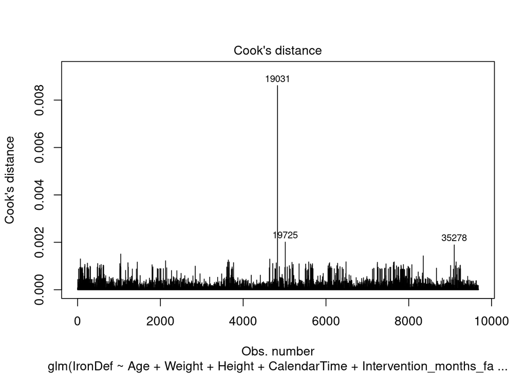

```r
#independent observations: yes, we checked clustering with the LMM and there is no longitudinal dependence.

#influential observations:
plot(ID_fit_preF, which = 4)
```

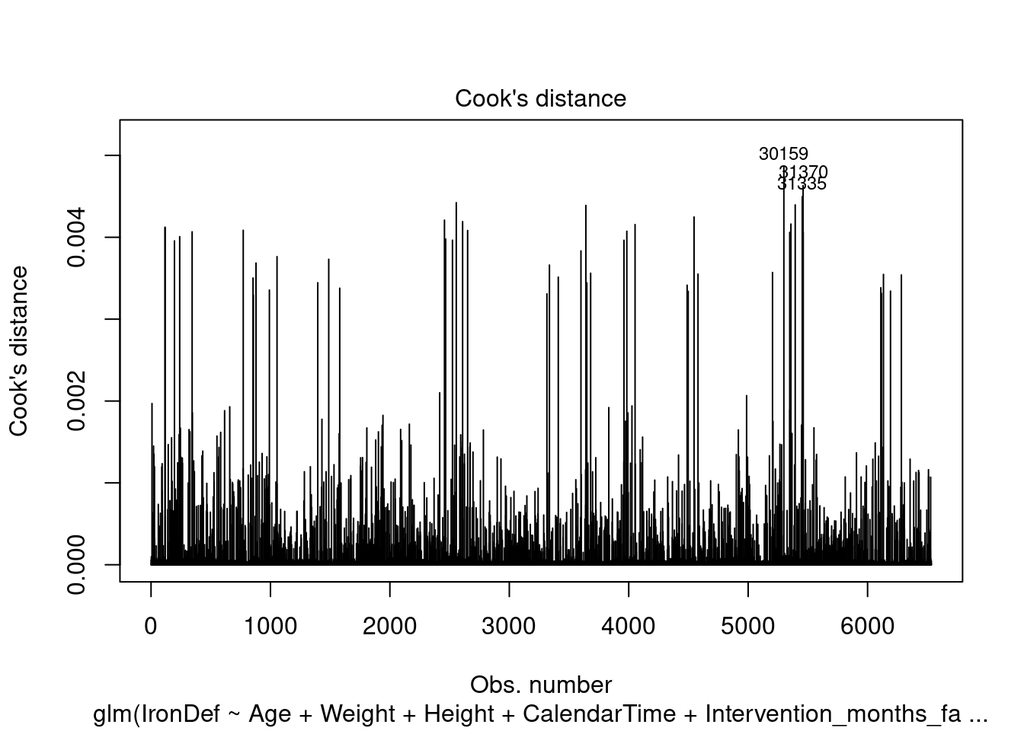

```r
plot(ID_fit_postF, which = 4)
```

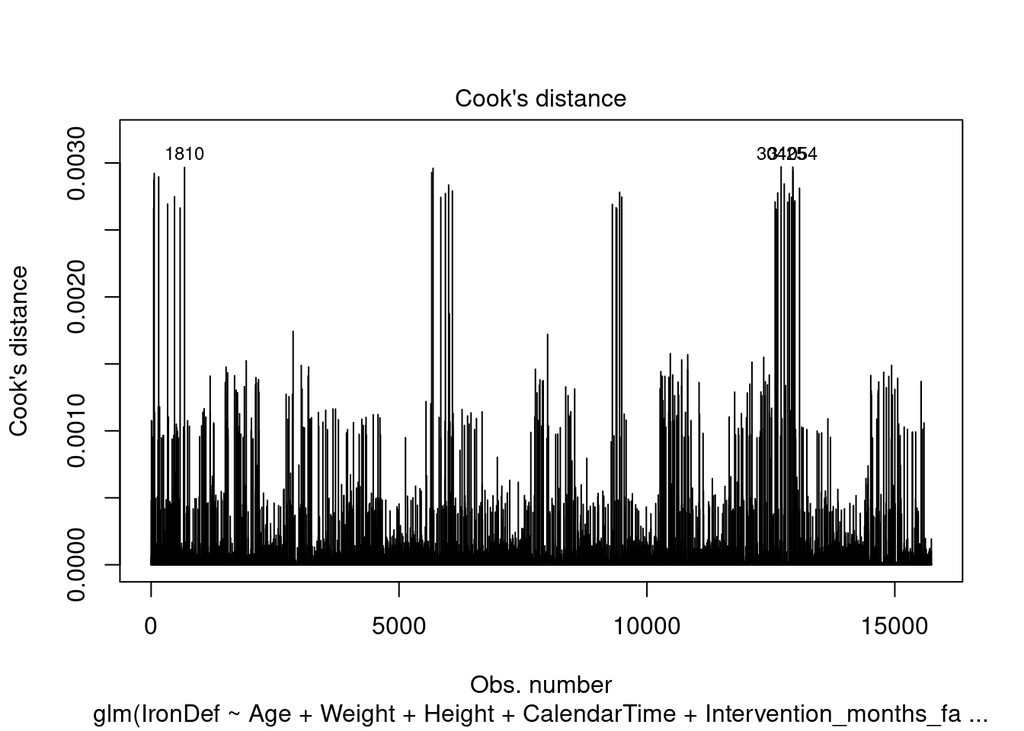

```r
plot(ID_fitM, which = 4)
```

```r
#no multicollinearity:

vif(ID_fit_preF)
```

```
                               GVIF Df GVIF^(1/(2*Df))
Age                        1.041335  1        1.020458
Weight                     1.177473  1        1.085114
Height                     1.137777  1        1.066666
CalendarTime               2.264230  1        1.504736
Intervention_months_factor 2.266024  6        1.070546
```

```r
vif(ID_fit_postF)
```

```
                               GVIF Df GVIF^(1/(2*Df))
Age                        1.030998  1        1.015381
Weight                     1.133147  1        1.064494
Height                     1.154607  1        1.074526
CalendarTime               2.137564  1        1.462041
Intervention_months_factor 2.140847  6        1.065489
```

```r
vif(ID_fitM)
```

```
                               GVIF Df GVIF^(1/(2*Df))
Age                        1.112062  1        1.054544
Weight                     1.294830  1        1.137906
Height                     1.288997  1        1.135340
CalendarTime               1.931769  1        1.389881
Intervention_months_factor 1.933848  6        1.056498
```

VIF is not above 4 for any of the covariates

### Donor return

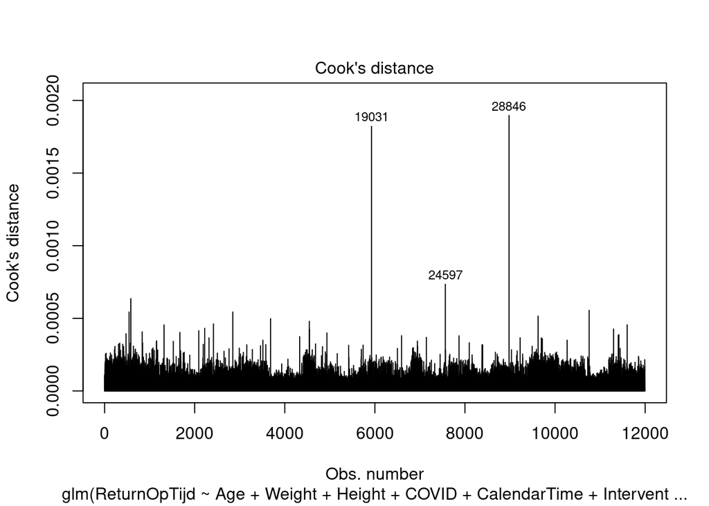

```r
#independent observations: yes, we checked clustering with the LMM and there is no longitudinal dependence.

#influential observations:
plot(returnOT_fit_preF, which = 4)
```

```r
model.data <- augment(returnOT_fit_preF) %>%
  dplyr::mutate(index = 1:n())
model.data %>% top_n(3, .cooksd)
```

```
# A tibble: 3 × 15
  .rownames ReturnOpTijd Age[,1] Weight[,1] Height[,1] COVID CalendarTime
  <chr>            <dbl>   <dbl>      <dbl>      <dbl> <fct>        <dbl>
1 19031                0   -17.2      -16.6    -101.   0                0
2 24597                0   -18.2       66.4       3.50 0               36
3 28846                0   -17.2      -18.6    -169.   1               24
# ℹ 8 more variables: Intervention_months_factor <fct>, .fitted <dbl>,
#   .resid <dbl>, .hat <dbl>, .sigma <dbl>, .cooksd <dbl>, .std.resid <dbl>,
#   index <int>
```

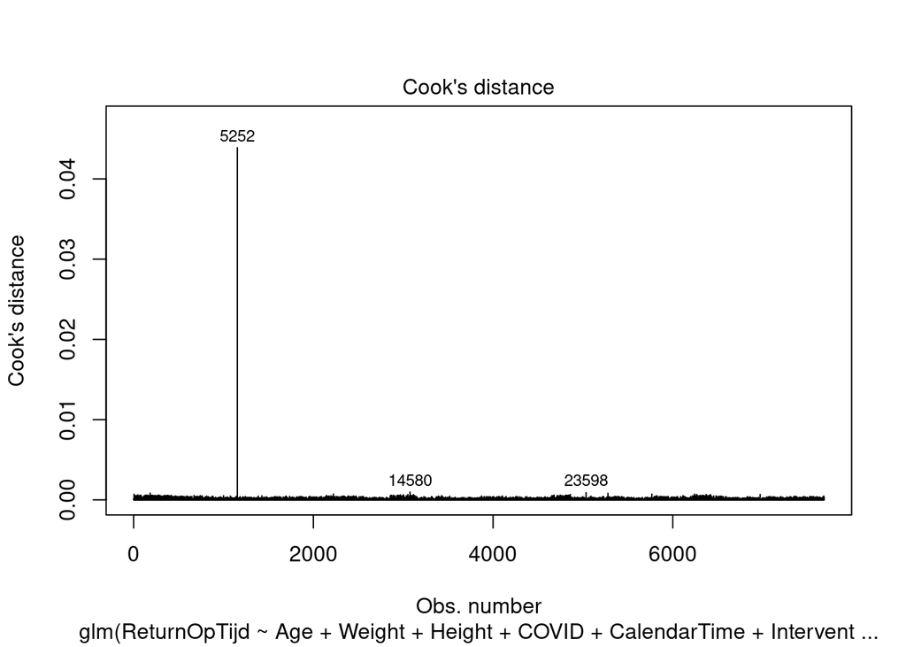

```r
plot(returnOT_fit_postF, which = 4)
```

```r
model.data <- augment(returnOT_fit_postF) %>%
  dplyr::mutate(index = 1:n())
model.data %>% top_n(3, .cooksd)
```

```
# A tibble: 3 × 15
  .rownames ReturnOpTijd Age[,1] Weight[,1] Height[,1] COVID CalendarTime
  <chr>            <dbl>   <dbl>      <dbl>      <dbl> <fct>        <dbl>
1 5252                 1   13.8       572.      -14.5  0               36
2 14580                0   14.8        61.4      -9.50 0               36
3 23598                0    3.78       71.4      -2.50 0               36
# ℹ 8 more variables: Intervention_months_factor <fct>, .fitted <dbl>,
#   .resid <dbl>, .hat <dbl>, .sigma <dbl>, .cooksd <dbl>, .std.resid <dbl>,
#   index <int>
```

Again some observations that stand out. However, the absolute standardized residuals are not above 3.

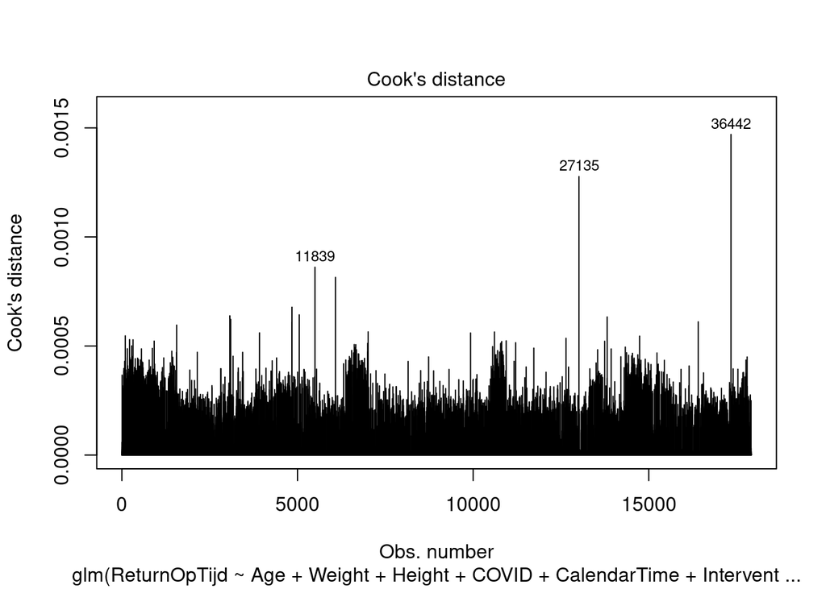

```r
plot(returnOT_fitM, which = 4)
```

```r
#no multicollinearity:

vif(returnOT_fit_preF)
```

```
                               GVIF Df GVIF^(1/(2*Df))
Age                        1.038731  1        1.019182
Weight                     1.152855  1        1.073711
Height                     1.115503  1        1.056174
COVID                      1.369995  1        1.170468
CalendarTime               2.673749  1        1.635160
Intervention_months_factor 3.379259  6        1.106798
```

```r
vif(returnOT_fit_postF)
```

```
                               GVIF Df GVIF^(1/(2*Df))
Age                        1.034538  1        1.017122
Weight                     1.084417  1        1.041353
Height                     1.110750  1        1.053921
COVID                      1.356850  1        1.164839
CalendarTime               2.743285  1        1.656287
Intervention_months_factor 3.441918  6        1.108494
```

```r
vif(returnOT_fitM)
```

```
                               GVIF Df GVIF^(1/(2*Df))
Age                        1.109098  1        1.053137
Weight                     1.281100  1        1.131857
Height                     1.270783  1        1.127290
COVID                      1.374742  1        1.172494
CalendarTime               2.857186  1        1.690321
Intervention_months_factor 3.583432  6        1.112222
```

VIF is not above 4 for any of the covariates

**Decision**